# Analysis_Creativity_Experiment

2025-07-09

```r
knitr::opts_chunk$set(echo = TRUE)
# Clear all ---------------------------------------------------------------
rm(list=ls())

# Install and load required packages
req <- substitute(require(x, character.only = TRUE))
libs <- c("psych", "dplyr", "skimr", "tidyverse", "tidyr", "ggplot2", "lme4", "lmerTest", "emmeans", "knitr", "gridExtra", "scales", "here", "ggh4x", "fmsb", "stargazer", "grid", "apaTables", "easystats", "qqplotr", "rstatix")
sapply(libs, function(x) eval(req) || {install.packages(x, dependencies = T); eval(req)})
```

[output not shown]

```
##     psych     dplyr     skimr tidyverse     tidyr   ggplot2      lme4  lmerTest
##      TRUE      TRUE      TRUE      TRUE      TRUE      TRUE      TRUE      TRUE
##   emmeans     knitr gridExtra    scales      here     ggh4x      fmsb stargazer
##      TRUE      TRUE      TRUE      TRUE      TRUE      TRUE      TRUE      TRUE
##      grid apaTables easystats   qqplotr   rstatix
##      TRUE      TRUE      TRUE      TRUE      TRUE
```

```r
# Global color palette -----------------------------------------------------
# Discrete palette to be used consistently across all ggplot2 plots
ac_palette <- c(
  "#7A9E7E", # Sage Green
  "#4F6D7A", # Slate Blue
  "#5DA9A8", # Muted Teal
  "#A398B3", # Dusty Lavender
  "#D9CFC1", # Warm Sand
  "#4A4A4A"  # Charcoal
)

# Make the palette the default for discrete colour/fill scales
scale_colour_discrete <- function(...) ggplot2::scale_colour_manual(..., values = ac_palette)
scale_color_discrete   <- scale_colour_discrete
scale_fill_discrete    <- function(...) ggplot2::scale_fill_manual(..., values = ac_palette)

# STANDARDIZED BOT ORDER FOR ALL GRAPHICS: feedback, suggestion, improvement, vanilla, control
# (Question-mode, Suggestion-mode, Model-led, Vanilla, Control)

# Global bot-type label map (two-line variants for readability)
label_map <- c(
  control     = "Control",
  vanilla     = "Vanilla",
  feedback    = "Question-Mode",
  improvement = "Model-Led",
  suggestion  = "Suggestion-Mode"
)

# Boxplot-specific label map with line breaks to prevent overlapping
boxplot_label_map <- c(
  control     = "Control",
  vanilla     = "Vanilla",
  feedback    = "Question-\nMode",
  improvement = "Model-\nLed",
  suggestion  = "Suggestion-\nMode"
)

# Global color palette for bot types
bot_colors <- c(
  vanilla     = "#A398B3", # Dusty Lavender
  feedback    = "#4F6D7A", # Slate Blue
  improvement = "#5DA9A8", # Muted Teal
  suggestion  = "#7A9E7E", # Sage Green
  control     = "#D9CFC1"  # Warm Sand
)


# Set project root directory using here package for reproducible paths
library(here)
project_root <- here::here()

# Set working directory to project root
knitr::opts_knit$set(root.dir = project_root)

# Helper path builders using explicit project root
data_path <- function(...) file.path(project_root, "analysis", "Study1", "data", ...)
fig_path  <- function(...) file.path(project_root, "analysis", "Study1", "figures", ...)
code_path <- function(...) file.path(project_root, "analysis", "Code", ...)
analysis_path <- function(...) file.path(project_root, "analysis", ...)
```

#Overview

```
## [1] 486  67
```

[output not shown]

[output cut: 128 more lines]

[output not shown]

[output cut: 117 more lines]

```
## 'data.frame':    486 obs. of  67 variables:
##  $ participant_id                 : chr  "P8243" "P0720" "P8922" "P4922" ...
##  $ row_type                       : chr  "submission" "submission" "submission" "submission" ...
##  $ bot_type                       : chr  "feedback" "feedback" "control" "feedback" ...
##  $ idea                           : chr  "The headlights of the car could record what they are 'seeing' and give a narrative to the driver and passengers." "I would repurpose the headlights into hanging downlighters that could be used in retro bars. " "I would take the screens from cars and put t…
##  $ questionnaire_completed        : chr  "Yes" "Yes" "Yes" "Yes" ...
##  $ ac1                            : int  2 2 2 2 2 2 2 2 2 2 ...
##  $ ac2                            : int  5 5 5 5 5 5 5 5 5 5 ...
##  $ ai1                            : int  2 1 1 4 5 4 3 4 3 3 ...
##  $ cse1                           : int  4 4 3 6 7 4 4 6 4 6 ...
##  $ cse2                           : int  4 5 4 6 7 2 4 7 4 5 ...
##  $ cse3                           : int  5 5 3 6 7 3 2 6 4 5 ...
##  $ ee1                            : int  6 7 NA 7 7 6 6 6 6 5 ...
##  $ ee2                            : int  6 7 NA 7 7 6 5 6 5 4 ...
##  $ ee3                            : int  6 7 NA 7 7 6 5 6 6 5 ...
```

[output cut: 53 more lines]

```
##  participant_id       row_type           bot_type             idea
##  Length:486         Length:486         Length:486         Length:486
##  Class :character   Class :character   Class :character   Class :character
##  Mode  :character   Mode  :character   Mode  :character   Mode  :character
##
##
##
##
##  questionnaire_completed      ac1         ac2         ai1
##  Length:486              Min.   :2   Min.   :5   Min.   :1.000
##  Class :character        1st Qu.:2   1st Qu.:5   1st Qu.:2.000
##  Mode  :character        Median :2   Median :5   Median :3.000
##                          Mean   :2   Mean   :5   Mean   :3.216
##                          3rd Qu.:2   3rd Qu.:5   3rd Qu.:4.000
##                          Max.   :2   Max.   :5   Max.   :5.000
##
##       cse1            cse2            cse3            ee1
##  Min.   :1.000   Min.   :1.000   Min.   :1.000   Min.   :1.000
##  1st Qu.:4.000   1st Qu.:4.000   1st Qu.:4.000   1st Qu.:6.000
##  Median :5.000   Median :5.000   Median :5.000   Median :6.000
##  Mean   :4.802   Mean   :5.045   Mean   :4.484   Mean   :6.088
##  3rd Qu.:6.000   3rd Qu.:6.000   3rd Qu.:5.000   3rd Qu.:7.000
##  Max.   :7.000   Max.   :7.000   Max.   :7.000   Max.   :7.000
##                                                  NA's   :99
##       ee2             ee3             ee4             hm1
##  Min.   :1.000   Min.   :1.000   Min.   :1.000   Min.   :1.000
##  1st Qu.:5.000   1st Qu.:5.000   1st Qu.:5.000   1st Qu.:4.000
##  Median :6.000   Median :6.000   Median :6.000   Median :6.000
##  Mean   :5.964   Mean   :5.972   Mean   :5.718   Mean   :5.282
##  3rd Qu.:7.000   3rd Qu.:7.000   3rd Qu.:7.000   3rd Qu.:7.000
##  Max.   :7.000   Max.   :7.000   Max.   :7.000   Max.   :7.000
##  NA's   :99      NA's   :99      NA's   :99      NA's   :99
##       hm2             hm3             io1             io2
##  Min.   :1.000   Min.   :1.000   Min.   :1.000   Min.   :1.000
##  1st Qu.:4.000   1st Qu.:4.000   1st Qu.:5.000   1st Qu.:5.000
##  Median :5.000   Median :6.000   Median :6.000   Median :6.000
##  Mean   :5.018   Mean   :5.264   Mean   :5.325   Mean   :5.467
##  3rd Qu.:6.000   3rd Qu.:7.000   3rd Qu.:7.000   3rd Qu.:7.000
##  Max.   :7.000   Max.   :7.000   Max.   :7.000   Max.   :7.000
##  NA's   :99      NA's   :99
```

[output cut: 89 more lines]

```
##  Min.   :1.000     Min.   :1.000      Min.   :1.333
##  1st Qu.:5.500     1st Qu.:4.333      1st Qu.:3.000
##  Median :6.000     Median :5.667      Median :3.833
##  Mean   :5.935     Mean   :5.188      Mean   :3.682
##  3rd Qu.:6.750     3rd Qu.:6.333      3rd Qu.:4.333
##  Max.   :7.000     Max.   :7.000      Max.   :5.333
##  NA's   :99        NA's   :99
##  Perceived_Ownership
##  Min.   :1.400
##  1st Qu.:4.600
##  Median :5.600
##  Mean   :5.417
##  3rd Qu.:6.400
##  Max.   :7.000
##
```

```
##  [1] "participant_id"                  "row_type"
##  [3] "bot_type"                        "idea"
##  [5] "questionnaire_completed"         "ac1"
##  [7] "ac2"                             "ai1"
##  [9] "cse1"                            "cse2"
## [11] "cse3"                            "ee1"
## [13] "ee2"                             "ee3"
## [15] "ee4"                             "hm1"
## [17] "hm2"                             "hm3"
## [19] "io1"                             "io2"
## [21] "io3"                             "io4"
## [23] "io5"                             "pe1"
## [25] "pe2"                             "pe3"
## [27] "pta1"                            "pta2"
## [29] "pta3"                            "pta4"
```

[output cut: 19 more lines]

Data summary

| Name | data_clean |
| --- | --- |
| Number of rows | 486 |
| Number of columns | 67 |
| _______________________ |  |
| Column type frequency: |  |
| character | 9 |
| numeric | 58 |
| ________________________ |  |
| Group variables | None |

**Variable type: character**

| skim_variable | n_missing | complete_rate | min | max | empty | n_unique | whitespace |
| --- | --- | --- | --- | --- | --- | --- | --- |
| participant_id | 0 | 1 | 5 | 5 | 0 | 486 | 0 |
| row_type | 0 | 1 | 10 | 15 | 0 | 2 | 0 |
| bot_type | 0 | 1 | 7 | 11 | 0 | 5 | 0 |
| idea | 0 | 1 | 0 | 2215 | 97 | 390 | 0 |
| questionnaire_completed | 0 | 1 | 3 | 3 | 0 | 1 | 0 |
| honesty_question_answer | 0 | 1 | 2 | 2 | 0 | 1 | 0 |
| refined_idea | 0 | 1 | 36 | 5072 | 0 | 486 | 0 |
| Status | 0 | 1 | 8 | 8 | 0 | 1 | 0 |
| Sex | 0 | 1 | 4 | 17 | 0 | 3 | 0 |

**Variable type: numeric**

| skim_variable | n_missing | complete_rate | mean | sd | p0 | p25 | p50 | p75 | p100 | hist |
| --- | --- | --- | --- | --- | --- | --- | --- | --- | --- | --- |
| ac1 | 0 | 1.0 | 2.00 | 0.00 | 2.00 | 2.00 | 2.00 | 2.00 | 2.00 | ▁▁▇▁▁ |
| ac2 | 0 | 1.0 | 5.00 | 0.00 | 5.00 | 5.00 | 5.00 | 5.00 | 5.00 | ▁▁▇▁▁ |
| ai1 | 0 | 1.0 | 3.22 | 1.22 | 1.00 | 2.00 | 3.00 | 4.00 | 5.00 | ▂▆▇▆▅ |
| cse1 | 0 | 1.0 | 4.80 | 1.64 | 1.00 | 4.00 | 5.00 | 6.00 | 7.00 | ▂▂▃▅▇ |
| cse2 | 0 | 1.0 | 5.05 | 1.52 | 1.00 | 4.00 | 5.00 | 6.00 | 7.00 | ▂▁▃▅▇ |
| cse3 | 0 | 1.0 | 4.48 | 1.50 | 1.00 | 4.00 | 5.00 | 5.00 | 7.00 | ▃▃▆▇▇ |
| ee1 | 99 | 0.8 | 6.09 | 1.09 | 1.00 | 6.00 | 6.00 | 7.00 | 7.00 | ▁▁▁▁▇ |
| ee2 | 99 | 0.8 | 5.96 | 1.16 | 1.00 | 5.00 | 6.00 | 7.00 | 7.00 | ▁▁▁▂▇ |
| ee3 | 99 | 0.8 | 5.97 | 1.17 | 1.00 | 5.00 | 6.00 | 7.00 | 7.00 | ▁▁▁▂▇ |
| ee4 | 99 | 0.8 | 5.72 | 1.30 | 1.00 | 5.00 | 6.00 | 7.00 | 7.00 | ▁▁▁▂▇ |
| hm1 | 99 | 0.8 | 5.28 | 1.65 | 1.00 | 4.00 | 6.00 | 7.00 | 7.00 | ▁▁▂▂▇ |
| hm2 | 99 | 0.8 | 5.02 | 1.72 | 1.00 | 4.00 | 5.00 | 6.00 | 7.00 | ▂▁▃▃▇ |
| hm3 | 99 | 0.8 | 5.26 | 1.66 | 1.00 | 4.00 | 6.00 | 7.00 | 7.00 | ▁▁▂▂▇ |
| io1 | 0 | 1.0 | 5.33 | 1.54 | 1.00 | 5.00 | 6.00 | 7.00 | 7.00 | ▁▁▂▃▇ |
| io2 | 0 | 1.0 | 5.47 | 1.53 | 1.00 | 5.00 | 6.00 | 7.00 | 7.00 | ▁▁▁▂▇ |
| io3 | 0 | 1.0 | 5.57 | 1.41 | 1.00 | 5.00 | 6.00 | 7.00 | 7.00 | ▁▁▂▃▇ |
| io4 | 0 | 1.0 | 4.87 | 1.84 | 1.00 | 4.00 | 5.00 | 6.00 | 7.00 | ▃▂▂▃▇ |
| io5 | 0 | 1.0 | 5.86 | 1.47 | 1.00 | 5.00 | 6.00 | 7.00 | 7.00 | ▁▁▁▂▇ |
| pe1 | 99 | 0.8 | 5.51 | 1.52 | 1.00 | 5.00 | 6.00 | 7.00 | 7.00 | ▁▁▁▃▇ |
| pe2 | 99 | 0.8 | 5.45 | 1.62 | 1.00 | 5.00 | 6.00 | 7.00 | 7.00 | ▁▁▁▂▇ |
| pe3 | 99 | 0.8 | 5.50 | 1.55 | 1.00 | 5.00 | 6.00 | 7.00 | 7.00 | ▁▁▁▃▇ |
| pta1 | 99 | 0.8 | 2.91 | 1.16 | 1.00 | 2.00 | 3.00 | 4.00 | 5.00 | ▃▇▇▆▂ |
| pta2 | 99 | 0.8 | 2.91 | 1.17 | 1.00 | 2.00 | 3.00 | 4.00 | 5.00 | ▃▇▆▇▂ |
| pta3 | 99 | 0.8 | 3.42 | 1.03 | 1.00 | 3.00 | 4.00 | 4.00 | 5.00 | ▁▃▆▇▂ |
| pta4 | 99 | 0.8 | 3.01 | 0.90 | 1.00 | 2.00 | 3.00 | 4.00 | 5.00 | ▁▃▇▃▁ |
| pta5 | 99 | 0.8 | 3.04 | 1.05 | 1.00 | 2.00 | 3.00 | 4.00 | 5.00 | ▂▆▇▆▂ |
| ptt1 | 0 | 1.0 | 3.52 | 1.08 | 1.00 | 3.00 | 4.00 | 4.00 | 5.00 | ▁▂▃▇▃ |
| ptt2 | 0 | 1.0 | 2.49 | 1.17 | 1.00 | 2.00 | 2.00 | 3.00 | 5.00 | ▅▇▅▃▁ |
| ptt3 | 0 | 1.0 | 3.34 | 1.11 | 1.00 | 3.00 | 4.00 | 4.00 | 5.00 | ▂▃▃▇▂ |
| ptt4 | 0 | 1.0 | 3.24 | 1.08 | 1.00 | 3.00 | 3.00 | 4.00 | 5.00 | ▂▃▆▇▂ |
| ptt5 | 0 | 1.0 | 3.39 | 1.04 | 1.00 | 3.00 | 4.00 | 4.00 | 5.00 | ▁▂▆▇▂ |
| ptt6 | 0 | 1.0 | 3.10 | 1.12 | 1.00 | 2.00 | 3.00 | 4.00 | 5.00 | ▂▅▇▇▂ |
| tlx1 | 0 | 1.0 | 51.27 | 24.69 | 0.00 | 30.00 | 50.00 | 70.00 | 100.00 | ▃▆▇▇▃ |
| tlx2 | 0 | 1.0 | 55.14 | 24.60 | 0.00 | 40.00 | 60.00 | 75.00 | 100.00 | ▃▅▆▇▃ |
| total_study_time_seconds | 0 | 1.0 | 493.33 | 418.94 | 44.00 | 200.25 | 398.00 | 661.00 | 3591.00 | ▇▂▁▁▁ |
| Time.taken | 0 | 1.0 | 812.32 | 569.43 | 151.00 | 417.00 | 655.00 | 1024.50 | 3821.00 | ▇▂▁▁▁ |
| Age | 0 | 1.0 | 41.34 | 12.99 | 18.00 | 32.00 | 39.00 | 51.00 | 78.00 | ▅▇▆▃▁ |
| refined_div_allideas | 0 | 1.0 | 0.36 | 0.09 | 0.14 | 0.31 | 0.36 | 0.41 | 0.71 | ▂▇▇▂▁ |
| refined_div_condition | 0 | 1.0 | 0.35 | 0.10 | 0.13 | 0.28 | 0.34 | 0.41 | 0.74 | ▂▇▅▁▁ |
| idea_div_allideas | 97 | 0.8 | 0.40 | 0.13 | 0.15 | 0.30 | 0.40 | 0.49 | 0.84 | ▅▇▆▂▁ |
| idea_div_condition | 97 | 0.8 | 0.40 | 0.12 | 0.14 | 0.30 | 0.40 | 0.47 | 0.79 | ▅▇▇▃▁ |
| refined_div_to_initial_centroid | 95 | 0.8 | 0.38 | 0.10 | 0.12 | 0.33 | 0.39 | 0.43 | 0.73 | ▂▅▇▂▁ |
| Rater1 | 0 | 1.0 | 3.31 | 1.52 | 1.00 | 2.00 | 3.00 | 4.38 | 7.00 | ▇▇▅▃▃ |
| Rater2 | 0 | 1.0 | 3.21 | 0.96 | 1.00 | 2.50 | 3.00 | 4.00 | 6.50 | ▂▇▅▂▁ |
| Rater3 | 0 | 1.0 | 2.67 | 1.17 | 1.00 | 2.00 | 2.50 | 3.50 | 6.50 | ▇▆▃▂▁ |
| Rater4 | 0 | 1.0 | 2.19 | 0.97 | 1.00 | 1.50 | 2.00 | 2.50 | 6.50 | ▇▃▂▁▁ |
| Average | 0 | 1.0 | 2.85 | 0.79 | 1.00 | 2.25 | 2.88 | 3.38 | 5.25 | ▂▇▇▂▁ |
| LLM_experience | 0 | 1.0 | 3.22 | 1.22 | 1.00 | 2.00 | 3.00 | 4.00 | 5.00 | ▂▆▇▆▅ |
| Idea_quality | 0 | 1.0 | 2.85 | 0.79 | 1.00 | 2.25 | 2.88 | 3.38 | 5.25 | ▂▇▇▂▁ |
| ptt2_rev | 0 | 1.0 | 5.51 | 1.17 | 3.00 | 5.00 | 6.00 | 6.00 | 7.00 | ▁▃▅▇▅ |
| Creative_Self_Efficacy | 0 | 1.0 | 4.78 | 1.41 | 1.00 | 4.00 | 5.00 | 5.92 | 7.00 | ▁▂▃▇▅ |
| Perceived_Technology_Agency | 99 | 0.8 | 3.06 | 0.74 | 1.00 | 2.60 | 3.00 | 3.60 | 5.00 | ▁▆▇▅▁ |
| NASA_TLX | 0 | 1.0 | 53.20 | 23.19 | 0.00 | 37.50 | 55.00 | 70.00 | 100.00 | ▃▅▇▇▃ |
| Performance_Expectancy | 99 | 0.8 | 5.49 | 1.50 | 1.00 | 5.00 | 6.00 | 6.67 | 7.00 | ▁▁▂▅▇ |
| Effort_Expectancy | 99 | 0.8 | 5.94 | 1.07 | 1.00 | 5.50 | 6.00 | 6.75 | 7.00 | ▁▁▁▃▇ |
| Hedonic_Motivation | 99 | 0.8 | 5.19 | 1.62 | 1.00 | 4.33 | 5.67 | 6.33 | 7.00 | ▂▁▂▅▇ |
| Propensity_to_Trust_Technology | 0 | 1.0 | 3.68 | 0.95 | 1.33 | 3.00 | 3.83 | 4.33 | 5.33 | ▁▃▅▇▃ |
| Perceived_Ownership | 0 | 1.0 | 5.42 | 1.27 | 1.40 | 4.60 | 5.60 | 6.40 | 7.00 | ▁▂▃▆▇ |

#Create Logit Transformed Version of Diversity Measure

```r
# Check the range of refined_div_condition
summary(data_clean$refined_div_condition)
```

```
##    Min. 1st Qu.  Median    Mean 3rd Qu.    Max.
##  0.1269  0.2821  0.3376  0.3478  0.4060  0.7443
```

```r
# Check for exact 0 or 1 values (which would cause -Inf or Inf)
cat("Any exact 0 values?", any(data_clean$refined_div_condition == 0, na.rm = TRUE), "\n")
```

```
## Any exact 0 values? FALSE
```

```r
cat("Any exact 1 values?", any(data_clean$refined_div_condition == 1, na.rm = TRUE), "\n")
```

```
## Any exact 1 values? FALSE
```

```r
# Apply logit transformation using qlogis()
data_clean$refined_div_condition_logit <- qlogis(data_clean$refined_div_condition)

cat("\nRange of logit transformed diversity:",
    range(data_clean$refined_div_condition_logit, na.rm = TRUE), "\n")
```

```
##
## Range of logit transformed diversity: -1.928418 1.068391
```

```r
cat("Summary of logit transformed diversity:\n")
```

```
## Summary of logit transformed diversity:
```

```r
summary(data_clean$refined_div_condition_logit)
```

```
##    Min. 1st Qu.  Median    Mean 3rd Qu.    Max.
## -1.9284 -0.9340 -0.6738 -0.6556 -0.3807  1.0684
```

#Group Comparisons

```r
# Calculate group means and SDs for all variables
data_group <- data_clean %>%
  group_by(bot_type) %>%
  summarise(
    # Variables available to ALL participants
    Creative_Self_Efficacy_mean = mean(Creative_Self_Efficacy, na.rm = TRUE),
    Creative_Self_Efficacy_sd = sd(Creative_Self_Efficacy, na.rm = TRUE),

    Propensity_to_Trust_Technology_mean = mean(Propensity_to_Trust_Technology, na.rm = TRUE),
    Propensity_to_Trust_Technology_sd = sd(Propensity_to_Trust_Technology, na.rm = TRUE),

    # NASA-TLX (if available to all)
    NASA_TLX_mean = mean(rowMeans(select(cur_data(), starts_with("tlx")), na.rm = TRUE), na.rm = TRUE),
    NASA_TLX_sd = sd(rowMeans(select(cur_data(), starts_with("tlx")), na.rm = TRUE), na.rm = TRUE),

    # UX-related constructs (only for chatbot users, will be NA for control)
    Perceived_Technology_Agency_mean = mean(Perceived_Technology_Agency, na.rm = TRUE),
    Perceived_Technology_Agency_sd = sd(Perceived_Technology_Agency, na.rm = TRUE),

    Performance_Expectancy_mean = mean(Performance_Expectancy, na.rm = TRUE),
    Performance_Expectancy_sd = sd(Performance_Expectancy, na.rm = TRUE),

    Effort_Expectancy_mean = mean(Effort_Expectancy, na.rm = TRUE),
    Effort_Expectancy_sd = sd(Effort_Expectancy, na.rm = TRUE),

    Hedonic_Motivation_mean = mean(Hedonic_Motivation, na.rm = TRUE),
    Hedonic_Motivation_sd = sd(Hedonic_Motivation, na.rm = TRUE),

    Perceived_Ownership_mean = mean(Perceived_Ownership, na.rm = TRUE),
    Perceived_Ownership_sd = sd(Perceived_Ownership, na.rm = TRUE),

    AI_experience_mean = mean(ai1, na.rm = TRUE),
    AI_experience_sd = sd(ai1, na.rm = TRUE),

    IdeaQuality_mean = mean(Idea_quality, na.rm = TRUE),
    IdeaQuality_sd = sd(Idea_quality, na.rm = TRUE),

    #Embeddings based on refined ideas
    refined_div_allideas_mean = mean(refined_div_allideas, na.rm = TRUE),
    refined_div_allideas_sd = sd(refined_div_allideas, na.rm = TRUE),
    refined_div_condition_mean = mean(refined_div_condition, na.rm = TRUE),
    refined_div_condition_sd = sd(refined_div_condition, na.rm = TRUE),

    #Logit transformed diversity
    refined_div_condition_logit_mean = mean(refined_div_condition_logit, na.rm = TRUE),
    refined_div_condition_logit_sd = sd(refined_div_condition_logit, na.rm = TRUE),

    #Embeddings based on initial ideas
    ideas_div_allideas_mean = mean(idea_div_allideas, na.rm = TRUE),
    ideas_div_allideas_sd = sd(idea_div_allideas, na.rm = TRUE),
    ideas_div_condition_mean = mean(idea_div_condition, na.rm = TRUE),
    ideas_div_condition_sd = sd(idea_div_condition, na.rm = TRUE),


    Count_Observations = n()
  ) %>%
  ungroup()
# View the grouped data
print(data_group)
```

```
## # A tibble: 5 × 32
##   bot_type  Creative_Self_Effica…¹ Creative_Self_Effica…² Propensity_to_Trust_…³
##   <chr>                      <dbl>                  <dbl>                  <dbl>
## 1 control                     4.79                   1.49                   3.46
## 2 feedback                    5.09                   1.40                   3.89
## 3 improvem…                   4.63                   1.40                   3.57
## 4 suggesti…                   4.70                   1.29                   3.76
## 5 vanilla                     4.68                   1.44                   3.75
## # ℹ abbreviated names: ¹Creative_Self_Efficacy_mean,
## #   ²Creative_Self_Efficacy_sd, ³Propensity_to_Trust_Technology_mean
## # ℹ 28 more variables: Propensity_to_Trust_Technology_sd <dbl>,
## #   NASA_TLX_mean <dbl>, NASA_TLX_sd <dbl>,
## #   Perceived_Technology_Agency_mean <dbl>,
## #   Perceived_Technology_Agency_sd <dbl>, Performance_Expectancy_mean <dbl>,
## #   Performance_Expectancy_sd <dbl>, Effort_Expectancy_mean <dbl>, …
```

```r
write.csv(data_group, data_path("data_group_summary.csv"), row.names = FALSE)
```

#Correlation Matrix

```r
# Create correlation matrix with your study variables
correlation_matrix <- data_clean %>%
  dplyr::select(c(
    # Questionnaire constructs
    Idea_quality,
    Perceived_Ownership,
    refined_div_condition,
    Creative_Self_Efficacy,
    Propensity_to_Trust_Technology,
    NASA_TLX,
    Perceived_Technology_Agency,
    Performance_Expectancy,
    Effort_Expectancy,
    Hedonic_Motivation,
    LLM_experience,
    Age,
    total_study_time_seconds
  ))

# Create custom variable names for display
var_names <- c(
  "1. Idea Quality",
  "2. Perceived Ownership",
  "3. Refined Sim Condition Ideas",
  "4. Creative Self-Efficacy",
  "5. Propensity to Trust Technology",
  "6. NASA TLX",
  "7. Perceived Technology Agency",
  "8. Performance Expectancy",
  "9. Effort Expectancy",
  "10. Hedonic Motivation",
  "11. LLM Experience",
  "12. Age",
  "13. Total Study Time (Seconds)"
)

# Calculate correlations with significance tests
cor_result <- corr.test(correlation_matrix, use = "complete")
cor_matrix <- cor_result$r
p_matrix <- cor_result$p

# Create significance indicators
sig_matrix <- ifelse(p_matrix < 0.01, "**",
                    ifelse(p_matrix < 0.05, "*", ""))

# Format correlation matrix for display
cor_display <- cor_matrix
diag(cor_display) <- NA  # Remove diagonal
cor_display[lower.tri(cor_display)] <- NA  # Remove lower triangle

# Create formatted correlation strings
cor_formatted <- matrix("", nrow = nrow(cor_matrix), ncol = ncol(cor_matrix))
for(i in seq_len(nrow(cor_matrix))) {
  for(j in seq_len(ncol(cor_matrix))) {
    if(!is.na(cor_display[i,j])) {
      cor_formatted[i,j] <- paste0(sprintf("%.2f", cor_matrix[i,j]), sig_matrix[i,j])
    } else if(i == j) {
      cor_formatted[i,j] <- "---"
    }
  }
}

# Set row and column names
rownames(cor_formatted) <- var_names
colnames(cor_formatted) <- seq_len(ncol(cor_matrix))

# Calculate descriptive statistics
means <- sapply(correlation_matrix, mean, na.rm = TRUE)
sds <- sapply(correlation_matrix, sd, na.rm = TRUE)

# Create descriptive stats table
desc_stats <- data.frame(
  Variable = var_names,
  M = sprintf("%.2f", means),
  SD = sprintf("%.2f", sds),
  stringsAsFactors = FALSE
)

# APA-style correlation table (display only, no file saved)
# Use descriptive variable names as column headers for the APA table
colnames(correlation_matrix) <- var_names

apaTables::apa.cor.table(
  correlation_matrix,
  table.number = NA,
  filename = "Correlations"
)
```

```
##
##
## Means, standard deviations, and correlations with confidence intervals
##
##
##   Variable                             M      SD     1            2
##   1. 1. Idea Quality                   2.85   0.79
##
##   2. 2. Perceived Ownership            5.42   1.27   .02
##                                                      [-.07, .10]
##
##   3. 3. Refined Sim Condition Ideas    0.35   0.10   -.26**       .08
##                                                      [-.34, -.18] [-.01, .16]
##
##   4. 4. Creative Self-Efficacy         4.78   1.41   .10*         .62**
##                                                      [.01, .19]   [.56, .67]
##
##   5. 5. Propensity to Trust Technology 3.68   0.95   .06          .13**
##                                                      [-.03, .15]  [.05, .22]
##
##   6. 6. NASA TLX                       53.20  23.19  .04          .17**
##                                                      [-.05, .13]  [.08, .26]
##
##   7. 7. Perceived Technology Agency    3.06   0.74   -.06         -.21**
##                                                      [-.16, .04]  [-.30, -.11]
##
##   8. 8. Performance Expectancy         5.49   1.50   .11*         -.11*
##                                                      [.01, .21]   [-.20, -.01]
##
##   9. 9. Effort Expectancy              5.94   1.07   .07          .13*
##                                                      [-.03, .17]  [.03, .22]
##
##   10. 10. Hedonic Motivation           5.19   1.62   .08          .02
##                                                      [-.02, .18]  [-.08, .12]
##
##   11. 11. LLM Experience               3.22   1.22   .09*         .12**
##                                                      [.01, .18]   [.03, .20]
##
##   12. 12. Age                          41.34  12.99  .02          -.01
##                                                      [-.07, .11]  [-.10, .08]
```

[output cut: 74 more lines]

```
##   [.10, .30]  [.22, .40]
##
##   -.09        -.01        -.17**
##   [-.18, .01] [-.11, .09] [-.26, -.08]
##
##   .01         .04         .00          .21**
##   [-.09, .11] [-.06, .14] [-.09, .09]  [.12, .29]
##
##
## Note. M and SD are used to represent mean and standard deviation, respectively.
## Values in square brackets indicate the 95% confidence interval.
## The confidence interval is a plausible range of population correlations
## that could have caused the sample correlation (Cumming, 2014).
##  * indicates p < .05. ** indicates p < .01.
##
```

```r
# Note: apaTables already includes M and SD in the correlation table; no file is saved
```

# Creative Self-Efficacy

```r
CreativeSelfEfficacy <- data_clean %>%
  dplyr::select(., c(cse1, cse2, cse3))
alpha_CreativeSelfEfficacy <- psych::alpha(CreativeSelfEfficacy, check.keys = TRUE)
print(alpha_CreativeSelfEfficacy)
```

```
##
## Reliability analysis
## Call: psych::alpha(x = CreativeSelfEfficacy, check.keys = TRUE)
##
##   raw_alpha std.alpha G6(smc) average_r S/N    ase mean  sd median_r
##       0.89      0.89    0.85      0.73 8.3 0.0085  4.8 1.4      0.7
##
##     95% confidence boundaries
##          lower alpha upper
## Feldt     0.87  0.89  0.91
## Duhachek  0.88  0.89  0.91
##
##  Reliability if an item is dropped:
##      raw_alpha std.alpha G6(smc) average_r S/N alpha se var.r med.r
## cse1      0.83      0.83    0.70      0.70 4.7   0.0158    NA  0.70
## cse2      0.82      0.82    0.69      0.69 4.5   0.0165    NA  0.69
## cse3      0.89      0.89    0.81      0.81 8.3   0.0098    NA  0.81
##
##  Item statistics
##        n raw.r std.r r.cor r.drop mean  sd
## cse1 486  0.92  0.92  0.87   0.81  4.8 1.6
## cse2 486  0.92  0.92  0.88   0.82  5.0 1.5
## cse3 486  0.88  0.88  0.77   0.73  4.5 1.5
##
## Non missing response frequency for each item
##         1    2    3    4    5    6    7 miss
## cse1 0.04 0.07 0.12 0.15 0.24 0.22 0.16    0
## cse2 0.02 0.07 0.05 0.16 0.27 0.26 0.17    0
## cse3 0.03 0.08 0.12 0.23 0.28 0.16 0.09    0
```

# Perceived Cognitive Workload

```r
NASATLX <- data_clean %>%
  dplyr::select(., c(tlx1, tlx2))

# Inter-item Pearson correlation (2-item scale)
nasatlx_test <- cor.test(NASATLX$tlx1, NASATLX$tlx2, method = "pearson")
print(nasatlx_test)
```

```
##
##  Pearson's product-moment correlation
##
## data:  NASATLX$tlx1 and NASATLX$tlx2
## t = 26.565, df = 484, p-value < 2.2e-16
## alternative hypothesis: true correlation is not equal to 0
## 95 percent confidence interval:
##  0.7313253 0.8040389
## sample estimates:
##       cor
## 0.7701727
```

# Performance Expectancy

```r
PerformanceExpectancy <- data_clean %>%
  dplyr::select(., c(pe1, pe2, pe3))
alpha_PerformanceExpectancy <- psych::alpha(PerformanceExpectancy, check.keys = TRUE)
print(alpha_PerformanceExpectancy)
```

```
##
## Reliability analysis
## Call: psych::alpha(x = PerformanceExpectancy, check.keys = TRUE)
##
##   raw_alpha std.alpha G6(smc) average_r S/N    ase mean  sd median_r
##       0.95      0.95    0.93      0.87  21 0.0037  5.5 1.5     0.87
##
##     95% confidence boundaries
##          lower alpha upper
## Feldt     0.95  0.95  0.96
## Duhachek  0.95  0.95  0.96
##
##  Reliability if an item is dropped:
##     raw_alpha std.alpha G6(smc) average_r S/N alpha se var.r med.r
## pe1      0.94      0.94    0.89      0.89  16   0.0054    NA  0.89
## pe2      0.93      0.93    0.87      0.87  14   0.0062    NA  0.87
## pe3      0.92      0.92    0.86      0.86  12   0.0070    NA  0.86
##
##  Item statistics
##       n raw.r std.r r.cor r.drop mean  sd
## pe1 387  0.95  0.95  0.91   0.89  5.5 1.5
## pe2 387  0.96  0.96  0.92   0.90  5.4 1.6
## pe3 387  0.96  0.96  0.94   0.91  5.5 1.6
##
## Non missing response frequency for each item
##        1    2    3    4    5    6    7 miss
## pe1 0.03 0.03 0.04 0.08 0.21 0.30 0.30  0.2
## pe2 0.05 0.03 0.03 0.10 0.20 0.29 0.31  0.2
## pe3 0.04 0.04 0.03 0.07 0.21 0.31 0.30  0.2
```

# Effort Expectancy

```r
EffortExpectancy <- data_clean %>%
  dplyr::select(., c(ee1, ee2, ee3, ee4))
alpha_EffortExpectancy <- psych::alpha(EffortExpectancy, check.keys = TRUE)
print(alpha_EffortExpectancy)
```

```
##
## Reliability analysis
## Call: psych::alpha(x = EffortExpectancy, check.keys = TRUE)
##
##   raw_alpha std.alpha G6(smc) average_r S/N    ase mean  sd median_r
##       0.92      0.93    0.91      0.76  13 0.0056  5.9 1.1     0.77
##
##     95% confidence boundaries
##          lower alpha upper
## Feldt     0.91  0.92  0.93
## Duhachek  0.91  0.92  0.94
##
##  Reliability if an item is dropped:
##     raw_alpha std.alpha G6(smc) average_r  S/N alpha se   var.r med.r
## ee1      0.91      0.91    0.87      0.77  9.9   0.0074 0.00071  0.76
## ee2      0.89      0.90    0.86      0.74  8.7   0.0084 0.00217  0.74
## ee3      0.89      0.90    0.86      0.74  8.6   0.0083 0.00157  0.76
## ee4      0.92      0.92    0.88      0.78 10.9   0.0066 0.00022  0.79
##
##  Item statistics
##       n raw.r std.r r.cor r.drop mean  sd
## ee1 387  0.89  0.90  0.85   0.82  6.1 1.1
## ee2 387  0.92  0.92  0.89   0.85  6.0 1.2
## ee3 387  0.92  0.92  0.89   0.85  6.0 1.2
## ee4 387  0.89  0.88  0.82   0.79  5.7 1.3
##
## Non missing response frequency for each item
##        1    2    3    4    5    6    7 miss
## ee1 0.01 0.01 0.02 0.05 0.12 0.37 0.42  0.2
## ee2 0.01 0.01 0.02 0.07 0.16 0.34 0.40  0.2
## ee3 0.01 0.00 0.03 0.06 0.16 0.34 0.40  0.2
## ee4 0.02 0.01 0.03 0.11 0.19 0.33 0.33  0.2
```

# Hedonic Motivation

```r
HedonicMotivation <- data_clean %>%
  dplyr::select(., c(hm1, hm2, hm3))
alpha_HedonicMotivation <- psych::alpha(HedonicMotivation, check.keys = TRUE)
print(alpha_HedonicMotivation)
```

```
##
## Reliability analysis
## Call: psych::alpha(x = HedonicMotivation, check.keys = TRUE)
##
##   raw_alpha std.alpha G6(smc) average_r S/N    ase mean  sd median_r
##       0.97      0.97    0.95      0.91  31 0.0025  5.2 1.6     0.91
##
##     95% confidence boundaries
##          lower alpha upper
## Feldt     0.96  0.97  0.97
## Duhachek  0.96  0.97  0.97
##
##  Reliability if an item is dropped:
##     raw_alpha std.alpha G6(smc) average_r S/N alpha se var.r med.r
## hm1      0.95      0.95    0.91      0.91  20   0.0043    NA  0.91
## hm2      0.96      0.96    0.93      0.93  26   0.0033    NA  0.93
## hm3      0.94      0.94    0.89      0.89  17   0.0052    NA  0.89
##
##  Item statistics
##       n raw.r std.r r.cor r.drop mean  sd
## hm1 387  0.97  0.97  0.95   0.93  5.3 1.6
## hm2 387  0.96  0.96  0.93   0.92  5.0 1.7
## hm3 387  0.98  0.98  0.96   0.95  5.3 1.7
##
## Non missing response frequency for each item
##        1    2    3    4    5    6    7 miss
## hm1 0.04 0.04 0.07 0.11 0.18 0.29 0.27  0.2
## hm2 0.05 0.06 0.07 0.17 0.19 0.21 0.24  0.2
## hm3 0.04 0.05 0.06 0.13 0.17 0.27 0.27  0.2
```

# Perceived Ownership

```r
PerceivedOwnership <- data_clean %>%
  dplyr::select(., c(io1, io2, io3, io4, io5))
alpha_PerceivedOwnership <- psych::alpha(PerceivedOwnership, check.keys = TRUE)
print(alpha_PerceivedOwnership)
```

```
##
## Reliability analysis
## Call: psych::alpha(x = PerceivedOwnership, check.keys = TRUE)
##
##   raw_alpha std.alpha G6(smc) average_r S/N    ase mean  sd median_r
##       0.87      0.88    0.87      0.58   7 0.0091  5.4 1.3     0.63
##
##     95% confidence boundaries
##          lower alpha upper
## Feldt     0.85  0.87  0.89
## Duhachek  0.85  0.87  0.89
##
##  Reliability if an item is dropped:
##     raw_alpha std.alpha G6(smc) average_r  S/N alpha se  var.r med.r
## io1      0.82      0.82    0.81      0.53  4.6   0.0137 0.0380  0.52
## io2      0.81      0.82    0.80      0.53  4.5   0.0139 0.0317  0.52
## io3      0.82      0.82    0.81      0.54  4.7   0.0130 0.0406  0.54
## io4      0.86      0.86    0.85      0.60  6.0   0.0109 0.0439  0.59
## io5      0.90      0.91    0.89      0.72 10.3   0.0072 0.0064  0.72
##
##  Item statistics
##       n raw.r std.r r.cor r.drop mean  sd
## io1 486  0.89  0.89  0.88   0.82  5.3 1.5
## io2 486  0.90  0.90  0.90   0.83  5.5 1.5
## io3 486  0.87  0.88  0.86   0.80  5.6 1.4
## io4 486  0.82  0.80  0.72   0.67  4.9 1.8
## io5 486  0.60  0.62  0.45   0.42  5.9 1.5
##
## Non missing response frequency for each item
##        1    2    3    4    5    6    7 miss
## io1 0.01 0.06 0.07 0.09 0.23 0.27 0.27    0
## io2 0.01 0.05 0.07 0.10 0.18 0.28 0.31    0
## io3 0.01 0.04 0.05 0.10 0.22 0.26 0.32    0
## io4 0.04 0.12 0.08 0.14 0.17 0.20 0.25    0
## io5 0.02 0.04 0.03 0.05 0.17 0.24 0.46    0
```

# Reliability Summary

```r
# Cronbach's alpha for multi-item scales (excluding 2-item NASA-TLX)
reliability_summary <- data.frame(
  Scale = c(
           "Performance Expectancy", "Effort Expectancy", "Hedonic Motivation",
            "Perceived Ownership"),
  Cronbachs_Alpha = c(
    alpha_PerformanceExpectancy$total$raw_alpha,
    alpha_EffortExpectancy$total$raw_alpha,
    alpha_HedonicMotivation$total$raw_alpha,
    alpha_PerceivedOwnership$total$raw_alpha
  ),
  Items = c(3, 4, 3, 5)
)

knitr::kable(reliability_summary, digits = 3, caption = "Cronbach's Alpha for Multi-item Scales")
```

Cronbach’s Alpha for Multi-item Scales

| Scale | Cronbachs_Alpha | Items |
| --- | --- | --- |
| Performance Expectancy | 0.953 | 3 |
| Effort Expectancy | 0.925 | 4 |
| Hedonic Motivation | 0.968 | 3 |
| Perceived Ownership | 0.872 | 5 |

```r
# Inter-item Pearson r for NASA-TLX (2 items)
nasatlx_test <- cor.test(data_clean$tlx1, data_clean$tlx2, method = "pearson")
nasatlx_reliability <- data.frame(
  Scale = "NASA-TLX (2 items)",
  Pearson_r = round(unname(nasatlx_test$estimate), 3),
  CI_low = round(nasatlx_test$conf.int[1], 3),
  CI_high = round(nasatlx_test$conf.int[2], 3),
  p_value = signif(nasatlx_test$p.value, 3)
)
knitr::kable(nasatlx_reliability, digits = 3, caption = "Inter-item Pearson correlation for NASA-TLX")
```

Inter-item Pearson correlation for NASA-TLX

| Scale | Pearson_r | CI_low | CI_high | p_value |
| --- | --- | --- | --- | --- |
| NASA-TLX (2 items) | 0.77 | 0.731 | 0.804 | 0 |

#Rater reliability: ICC

```r
# More comprehensive analysis
rater_data <- data.frame(
  Rater1 = as.numeric(data_clean$Rater1),
  Rater2 = as.numeric(data_clean$Rater2),
  Rater3 = as.numeric(data_clean$Rater3),
  Rater4 = as.numeric(data_clean$Rater4)
)

# Calculate ICC
icc_result <- ICC(rater_data)
print(icc_result)
```

```
## Call: ICC(x = rater_data)
##
## Intraclass correlation coefficients
##                          type  ICC   F df1  df2       p lower bound upper bound
## Single_raters_absolute   ICC1 0.20 2.0 485 1458 3.3e-22        0.15        0.24
## Single_random_raters     ICC2 0.23 2.5 485 1455 8.3e-40        0.16        0.30
## Single_fixed_raters      ICC3 0.27 2.5 485 1455 8.3e-40        0.23        0.32
## Average_raters_absolute ICC1k 0.49 2.0 485 1458 3.3e-22        0.41        0.56
## Average_random_raters   ICC2k 0.54 2.5 485 1455 8.3e-40        0.42        0.63
## Average_fixed_raters    ICC3k 0.60 2.5 485 1455 8.3e-40        0.54        0.65
##
##  Number of subjects = 486     Number of Judges =  4
## See the help file for a discussion of the other 4 McGraw and Wong estimates,
```

```r
#ICC3,k relevant in our context
```

## Build Models for Diagnostics

```r
# Set factor levels for bot_type
data_clean$bot_type <- factor(data_clean$bot_type,
                            levels = c("feedback", "suggestion", "improvement", "vanilla", "control"))

# Model 1: Idea Quality (Linear Model)
quality_model <- lm(Average ~ bot_type, data = data_clean)

# Model 2: Idea Diversity (Linear Model)
DIV_model <- lm(refined_div_condition ~ bot_type, data = data_clean)

# Model 2b: Idea Diversity - Logit Transformed (Linear Model)
DIV_logit_model <- lm(refined_div_condition_logit ~ bot_type, data = data_clean)

# Model 3: Perceived Ownership (Linear Model)
PO_model <- lm(Perceived_Ownership ~ bot_type, data = data_clean)
```

## Assumption Tests: Linear Model (Idea Quality)

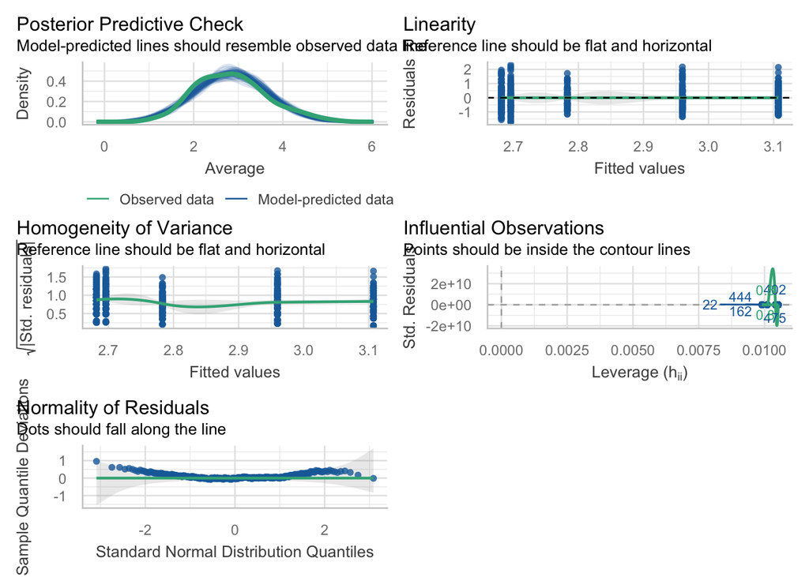

```r
Model_Quality <- check_model(
  quality_model)
Model_Quality
```

```r
check_heteroscedasticity(quality_model)
```

```
## OK: Error variance appears to be homoscedastic (p = 0.209).
```

```r
check_normality(quality_model)
```

[output not shown]

```r
# Save the full check_model composite plot as PDF (large enough for readability)
pdf(fig_path("diagnostics_quality_full_check_model.pdf"), width = 14, height = 6)
plot(Model_Quality)
```

```
## Ignoring unknown labels:
## • size : ""
```

```r
dev.off()
```

## Assumption Tests: Linear Model (Idea Diversity)

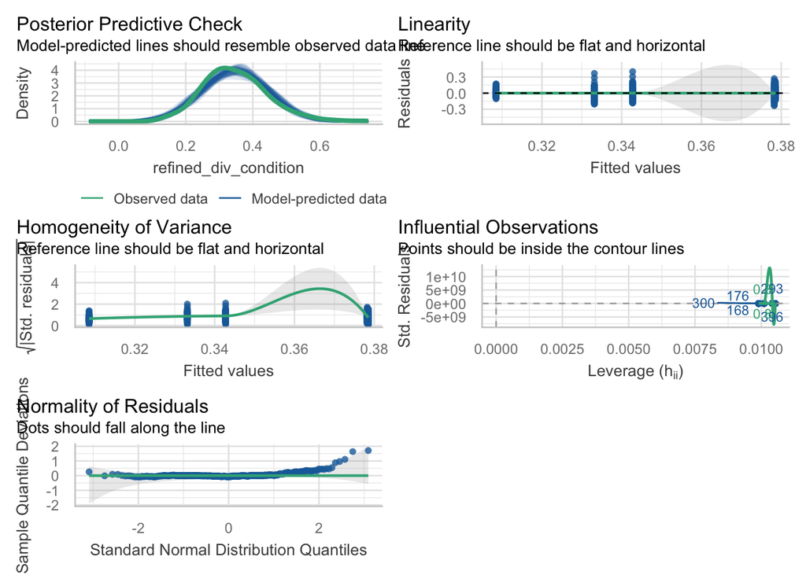

```r
Model_DIV <- check_model(
  DIV_model)
Model_DIV
```

```r
check_heteroscedasticity(DIV_model)
check_normality(DIV_model)
```

[output not shown]

```r
# Save the full check_model composite plot as PDF (large enough for readability)
pdf(fig_path("diagnostics_diversity_full_check_model.pdf"), width = 14, height = 10)
plot(Model_DIV)
```

```
## Ignoring unknown labels:
## • size : ""
```

```r
dev.off()
```

```r
# Create combined plot with 5 panels: 4 from original + 1 logit homogeneity
Model_DIV_pp <- check_model(DIV_model, check = "pp_check")
Model_DIV_homog <- check_model(DIV_model, check = "homogeneity")
Model_DIV_outliers <- check_model(DIV_model, check = "outliers")
Model_DIV_qq <- check_model(DIV_model, check = "qq")
Model_DIV_logit_homog <- check_model(DIV_logit_model, check = "homogeneity")

pdf(fig_path("diagnostics_diversity_with_logit_homogeneity.pdf"), width = 14, height = 10)
gridExtra::grid.arrange(
  plot(Model_DIV_pp),
  plot(Model_DIV_homog) + labs(title = "Homogeneity of Variance (Original)"),
  plot(Model_DIV_outliers),
  plot(Model_DIV_qq),
  plot(Model_DIV_logit_homog) + labs(title = "Homogeneity of Variance (Logit-Transformed)"),
  ncol = 2,
  nrow = 3
)
```

```
## Ignoring unknown labels:
## • size : ""
## Ignoring unknown labels:
## • size : ""
```

```r
dev.off()
```

## Assumption Tests: Linear Model (Idea Diversity - Logit Transformed)

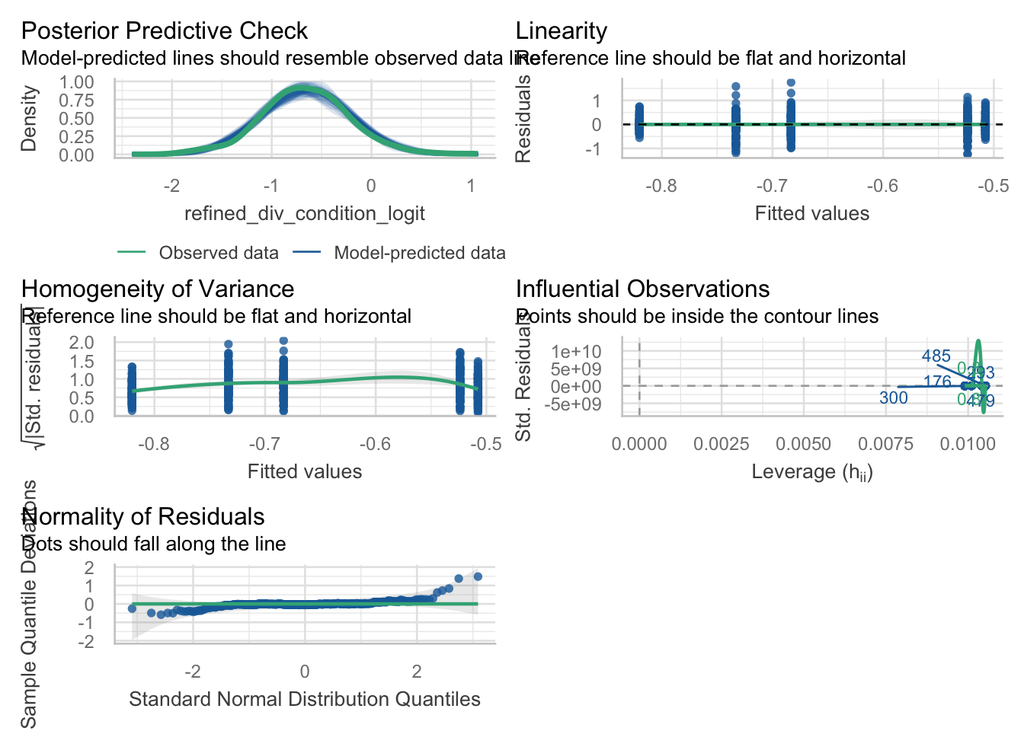

```r
Model_DIV_logit <- check_model(
  DIV_logit_model)
Model_DIV_logit
```

```r
check_heteroscedasticity(DIV_logit_model)
```

```
## OK: Error variance appears to be homoscedastic (p = 0.355).
```

```r
# Save the full check_model composite plot as PDF (large enough for readability)
pdf(fig_path("diagnostics_diversity_logit_full_check_model.pdf"), width = 14, height = 10)
plot(Model_DIV_logit)
```

```
## Ignoring unknown labels:
## • size : ""
```

```r
dev.off()
```

## Assumption Tests: Linear Model (Perceived Ownership)

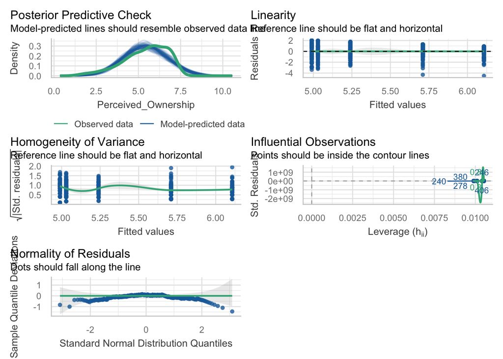

```r
Model_PO <- check_model(
  PO_model)
Model_PO
```

```r
check_heteroscedasticity(PO_model)
check_normality(PO_model)
```

[output not shown]

```r
# Save the full check_model composite plot as PDF (large enough for readability)
pdf(fig_path("diagnostics_ownership_full_check_model.pdf"), width = 10, height = 7)
plot(Model_PO)
```

```
## Ignoring unknown labels:
## • size : ""
```

```r
dev.off()
```

```r
data_clean$bot_type <- factor(data_clean$bot_type,
                            levels = c("feedback", "suggestion", "improvement", "vanilla", "control"))
levels(data_clean$bot_type)
```

```
## [1] "feedback"    "suggestion"  "improvement" "vanilla"     "control"
```

```r
# Fit the linear model
quality_model <- lm(Average ~ bot_type, data = data_clean)

# Summary and ANOVA
summary(quality_model)
```

```
##
## Call:
## lm(formula = Average ~ bot_type, data = data_clean)
##
## Residuals:
##      Min       1Q   Median       3Q      Max
## -1.69611 -0.57979 -0.07979  0.46695  2.30389
##
## Coefficients:
##                     Estimate Std. Error t value Pr(>|t|)
## (Intercept)          2.95979    0.07956  37.203   <2e-16 ***
## bot_typesuggestion  -0.17674    0.11281  -1.567   0.1178
## bot_typeimprovement  0.14744    0.11111   1.327   0.1852
## bot_typevanilla     -0.26369    0.11281  -2.337   0.0198 *
## bot_typecontrol     -0.27807    0.11166  -2.490   0.0131 *
## ---
## Signif. codes:  0 '***' 0.001 '**' 0.01 '*' 0.05 '.' 0.1 ' ' 1
##
## Residual standard error: 0.7795 on 481 degrees of freedom
## Multiple R-squared:  0.04358,    Adjusted R-squared:  0.03562
## F-statistic: 5.479 on 4 and 481 DF,  p-value: 0.0002548
```

```r
anova(quality_model)
```

```
## Analysis of Variance Table
##
## Response: Average
##            Df  Sum Sq Mean Sq F value    Pr(>F)
## bot_type    4  13.317  3.3292  5.4789 0.0002548 ***
## Residuals 481 292.272  0.6076
## ---
## Signif. codes:  0 '***' 0.001 '**' 0.01 '*' 0.05 '.' 0.1 ' ' 1
```

```r
# Estimate marginal means
quality_emm <- emmeans(quality_model, specs = ~ bot_type)

# Define contrasts for hypothesis testing
# Contrasts: feedback (Question-mode), suggestion (Suggestion-mode), improvement (Model-led), vanilla, control
contrast_list <- list(
  H1a = c(1,  0,  0,  0, -1),
  H1b = c(0, 1,  0,  0, -1),
  H1c = c(0,  0,  1,  0, -1),
  H1d = c( 0, 0,  0,  1, -1)
)

# Get Holm-adjusted p-values
contrast_adjusted <- contrast(quality_emm, method = contrast_list, adjust = "holm", infer = TRUE, side = ">")
print("Holm-adjusted p-values:")
```

```
## [1] "Holm-adjusted p-values:"
```

```r
print(contrast_adjusted)
```

```
##  contrast estimate    SE  df lower.CL upper.CL t.ratio p.value
##  H1a        0.2781 0.112 481    0.027      Inf   2.490  0.0196
##  H1b        0.1013 0.112 481   -0.150      Inf   0.905  0.3658
##  H1c        0.4255 0.110 481    0.178      Inf   3.860  0.0003
##  H1d        0.0144 0.112 481   -0.237      Inf   0.129  0.4489
##
## Confidence level used: 0.95
## Conf-level adjustment: bonferroni method for 4 estimates
## P value adjustment: holm method for 4 tests
## P values are right-tailed
```

```r
# Get unadjusted confidence intervals
contrast_unadjusted <- contrast(quality_emm, method = contrast_list, adjust = "none", infer = TRUE, side = ">")
print("Unadjusted confidence intervals:")
```

```
## [1] "Unadjusted confidence intervals:"
```

```r
print(contrast_unadjusted)
```

```
##  contrast estimate    SE  df lower.CL upper.CL t.ratio p.value
##  H1a        0.2781 0.112 481   0.0941      Inf   2.490  0.0065
##  H1b        0.1013 0.112 481  -0.0832      Inf   0.905  0.1829
##  H1c        0.4255 0.110 481   0.2438      Inf   3.860  0.0001
##  H1d        0.0144 0.112 481  -0.1701      Inf   0.129  0.4489
##
## Confidence level used: 0.95
## P values are right-tailed
```

```r
# Calculate effect sizes (Cohen's d)
# Get the residual standard deviation from the model
pooled_sd <- sigma(quality_model)

# Get contrast results
contrast_results <- contrast(quality_emm, method = contrast_list, adjust = "holm")


eff_size(quality_emm, method = contrast_list, sigma = pooled_sd, edf = df.residual(quality_model))
```

```
##  contrast effect.size    SE  df lower.CL upper.CL
##  H1a           0.3567 0.144 481   0.0744    0.639
##  H1b           0.1300 0.144 481  -0.1523    0.412
##  H1c           0.5459 0.143 481   0.2658    0.826
##  H1d           0.0185 0.144 481  -0.2637    0.301
##
## sigma used for effect sizes: 0.7795
## Confidence level used: 0.95
```

#H2:The diversity of the idea pool is higher when participants interact with a question mode LLM compared to (a) a model-led LLM and (b) a vanilla LLM.

#H3:The diversity of the idea pool is higher when participants interact with a suggestion mode LLM compared to (a) a model-led LLM and (b) a vanilla LLM.

```r
data_clean$bot_type <- factor(data_clean$bot_type,
                            levels = c("feedback", "suggestion", "improvement", "vanilla", "control"))
levels(data_clean$bot_type)
```

```
## [1] "feedback"    "suggestion"  "improvement" "vanilla"     "control"
```

```r
# Fit the linear model
DIV_model <- lm(refined_div_condition ~ bot_type, data = data_clean)

# Summary and ANOVA
summary(DIV_model)
```

```
##
## Call:
## lm(formula = refined_div_condition ~ bot_type, data = data_clean)
##
## Residuals:
##      Min       1Q   Median       3Q      Max
## -0.23296 -0.05871 -0.00924  0.05308  0.40155
##
## Coefficients:
##                       Estimate Std. Error t value Pr(>|t|)
## (Intercept)          0.3785095  0.0094118  40.217  < 2e-16 ***
## bot_typesuggestion  -0.0453607  0.0133452  -3.399 0.000732 ***
## bot_typeimprovement -0.0700007  0.0131445  -5.325 1.55e-07 ***
## bot_typevanilla     -0.0002642  0.0133452  -0.020 0.984215
## bot_typecontrol     -0.0357655  0.0132090  -2.708 0.007017 **
## ---
## Signif. codes:  0 '***' 0.001 '**' 0.01 '*' 0.05 '.' 0.1 ' ' 1
##
## Residual standard error: 0.09222 on 481 degrees of freedom
## Multiple R-squared:  0.08036,    Adjusted R-squared:  0.07272
## F-statistic: 10.51 on 4 and 481 DF,  p-value: 3.612e-08
```

```r
anova(DIV_model)
```

```
## Analysis of Variance Table
##
## Response: refined_div_condition
##            Df Sum Sq  Mean Sq F value    Pr(>F)
## bot_type    4 0.3574 0.089360  10.508 3.612e-08 ***
## Residuals 481 4.0903 0.008504
## ---
## Signif. codes:  0 '***' 0.001 '**' 0.01 '*' 0.05 '.' 0.1 ' ' 1
```

```r
# Estimate marginal means
SIM_emm <- emmeans(DIV_model, specs = ~ bot_type)

# Define contrasts for hypothesis testing
# Contrasts: feedback (Question-mode), suggestion (Suggestion-mode), improvement (Model-led), vanilla, control
contrast_list <- list(
  H2a = c(1,  0,  -1,  0, 0),
  H2b = c(1, 0,  0,  -1, 0),
  H3a = c(0,  1,  -1,  0, 0),
  H3b = c( 0, 1,  0,  -1, 0)
)

# Get Holm-adjusted p-values
contrast_adjusted <- contrast(SIM_emm, method = contrast_list, adjust = "holm", infer = TRUE, side = ">")
print("Holm-adjusted p-values:")
```

```
## [1] "Holm-adjusted p-values:"
```

```r
print(contrast_adjusted)
```

```
##  contrast  estimate     SE  df lower.CL upper.CL t.ratio p.value
##  H2a       0.070001 0.0131 481  0.04045      Inf   5.325  <.0001
##  H2b       0.000264 0.0133 481 -0.02974      Inf   0.020  0.9842
##  H3a       0.024640 0.0132 481 -0.00499      Inf   1.870  0.0932
##  H3b      -0.045096 0.0134 481 -0.07518      Inf  -3.370  0.9996
##
## Confidence level used: 0.95
## Conf-level adjustment: bonferroni method for 4 estimates
## P value adjustment: holm method for 4 tests
## P values are right-tailed
```

```r
# Get unadjusted confidence intervals
contrast_unadjusted <- contrast(SIM_emm, method = contrast_list, adjust = "none", infer = TRUE, side = ">")
print("Unadjusted confidence intervals:")
```

```
## [1] "Unadjusted confidence intervals:"
```

```r
print(contrast_unadjusted)
```

```
##  contrast  estimate     SE  df lower.CL upper.CL t.ratio p.value
##  H2a       0.070001 0.0131 481  0.04834      Inf   5.325  <.0001
##  H2b       0.000264 0.0133 481 -0.02173      Inf   0.020  0.4921
##  H3a       0.024640 0.0132 481  0.00292      Inf   1.870  0.0311
##  H3b      -0.045096 0.0134 481 -0.06715      Inf  -3.370  0.9996
##
## Confidence level used: 0.95
## P values are right-tailed
```

```r
# Calculate effect sizes (Cohen's d) for H2 & H3
eff_size(SIM_emm, method = contrast_list, sigma = sigma(DIV_model), edf = df.residual(DIV_model))
```

```
##  contrast effect.size    SE  df lower.CL upper.CL
##  H2a          0.75909 0.145 481   0.4749    1.043
##  H2b          0.00286 0.145 481  -0.2815    0.287
##  H3a          0.26720 0.143 481  -0.0141    0.549
##  H3b         -0.48903 0.146 481  -0.7758   -0.202
##
## sigma used for effect sizes: 0.09222
## Confidence level used: 0.95
```

#H2 & H3 with Logit Transformed Diversity: Robustness Check

The following analysis replicates H2 and H3 using logit-transformed diversity scores to assess whether results are robust to this transformation.

```r
data_clean$bot_type <- factor(data_clean$bot_type,
                            levels = c("feedback", "suggestion", "improvement", "vanilla", "control"))
levels(data_clean$bot_type)
```

```
## [1] "feedback"    "suggestion"  "improvement" "vanilla"     "control"
```

```r
# Fit the linear model with logit-transformed diversity
DIV_logit_model <- lm(refined_div_condition_logit ~ bot_type, data = data_clean)

# Summary and ANOVA
summary(DIV_logit_model)
```

```
##
## Call:
## lm(formula = refined_div_condition_logit ~ bot_type, data = data_clean)
##
## Residuals:
##      Min       1Q   Median       3Q      Max
## -1.24836 -0.24892 -0.01829  0.25739  1.75161
##
## Coefficients:
##                     Estimate Std. Error t value Pr(>|t|)
## (Intercept)         -0.50756    0.04302 -11.798  < 2e-16 ***
## bot_typesuggestion  -0.22551    0.06100  -3.697 0.000243 ***
## bot_typeimprovement -0.31263    0.06008  -5.203  2.9e-07 ***
## bot_typevanilla     -0.01617    0.06100  -0.265 0.791020
## bot_typecontrol     -0.17565    0.06038  -2.909 0.003790 **
## ---
## Signif. codes:  0 '***' 0.001 '**' 0.01 '*' 0.05 '.' 0.1 ' ' 1
##
## Residual standard error: 0.4215 on 481 degrees of freedom
## Multiple R-squared:  0.07708,    Adjusted R-squared:  0.06941
## F-statistic: 10.04 on 4 and 481 DF,  p-value: 8.172e-08
```

```r
anova(DIV_logit_model)
```

```
## Analysis of Variance Table
##
## Response: refined_div_condition_logit
##            Df Sum Sq Mean Sq F value    Pr(>F)
## bot_type    4  7.138 1.78442  10.044 8.172e-08 ***
## Residuals 481 85.457 0.17767
## ---
## Signif. codes:  0 '***' 0.001 '**' 0.01 '*' 0.05 '.' 0.1 ' ' 1
```

```r
# Estimate marginal means
SIM_logit_emm <- emmeans(DIV_logit_model, specs = ~ bot_type)

# Define contrasts for hypothesis testing (same as original H2 & H3)
# Contrasts: feedback (Question-mode), suggestion (Suggestion-mode), improvement (Model-led), vanilla, control
contrast_list <- list(
  H2a = c(1,  0,  -1,  0, 0),
  H2b = c(1, 0,  0,  -1, 0),
  H3a = c(0,  1,  -1,  0, 0),
  H3b = c( 0, 1,  0,  -1, 0)
)

# Get Holm-adjusted p-values
contrast_adjusted_logit <- contrast(SIM_logit_emm, method = contrast_list, adjust = "holm", infer = TRUE, side = ">")
print("Holm-adjusted p-values (logit transformed):")
```

```
## [1] "Holm-adjusted p-values (logit transformed):"
```

```r
print(contrast_adjusted_logit)
```

```
##  contrast estimate     SE  df lower.CL upper.CL t.ratio p.value
##  H2a        0.3126 0.0601 481   0.1775      Inf   5.203  <.0001
##  H2b        0.0162 0.0610 481  -0.1210      Inf   0.265  0.7910
##  H3a        0.0871 0.0602 481  -0.0483      Inf   1.446  0.2232
##  H3b       -0.2093 0.0612 481  -0.3469      Inf  -3.423  0.9997
##
## Confidence level used: 0.95
## Conf-level adjustment: bonferroni method for 4 estimates
## P value adjustment: holm method for 4 tests
## P values are right-tailed
```

```r
# Get unadjusted confidence intervals
contrast_unadjusted_logit <- contrast(SIM_logit_emm, method = contrast_list, adjust = "none", infer = TRUE, side = ">")
print("Unadjusted confidence intervals (logit transformed):")
```

```
## [1] "Unadjusted confidence intervals (logit transformed):"
```

```r
print(contrast_unadjusted_logit)
```

```
##  contrast estimate     SE  df lower.CL upper.CL t.ratio p.value
##  H2a        0.3126 0.0601 481   0.2136      Inf   5.203  <.0001
##  H2b        0.0162 0.0610 481  -0.0844      Inf   0.265  0.3955
##  H3a        0.0871 0.0602 481  -0.0122      Inf   1.446  0.0744
##  H3b       -0.2093 0.0612 481  -0.3101      Inf  -3.423  0.9997
##
## Confidence level used: 0.95
## P values are right-tailed
```

```r
# Calculate effect sizes (Cohen's d) for H2 & H3 with logit transformed data
eff_size(SIM_logit_emm, method = contrast_list, sigma = sigma(DIV_logit_model), edf = df.residual(DIV_logit_model))
```

```
##  contrast effect.size    SE  df lower.CL upper.CL
##  H2a           0.7417 0.145 481   0.4577    1.026
##  H2b           0.0384 0.145 481  -0.2460    0.323
##  H3a           0.2067 0.143 481  -0.0745    0.488
##  H3b          -0.4966 0.146 481  -0.7835   -0.210
##
## sigma used for effect sizes: 0.4215
## Confidence level used: 0.95
```

#H4: The perceived idea ownership is higher when participants interact with a question mode LLM compared to (a) a model-led LLM and (b) a vanilla LLM #H5: The perceived idea ownership is higher when participants interact with a suggestion mode LLM compared to (a) a model-led LLM and (b) a vanilla LLM

```r
data_clean$bot_type <- factor(data_clean$bot_type,
                            levels = c("feedback", "suggestion", "improvement", "vanilla", "control"))
levels(data_clean$bot_type)
```

```
## [1] "feedback"    "suggestion"  "improvement" "vanilla"     "control"
```

```r
# Fit the linear model
PO_model <- lm(Perceived_Ownership ~ bot_type, data = data_clean)

# Summary and ANOVA
summary(PO_model)
```

```
##
## Call:
## lm(formula = Perceived_Ownership ~ bot_type, data = data_clean)
##
## Residuals:
##     Min      1Q  Median      3Q     Max
## -4.5071 -0.7104  0.1651  0.8929  2.0105
##
## Coefficients:
##                     Estimate Std. Error t value Pr(>|t|)
## (Intercept)           5.7104     0.1226  46.562  < 2e-16 ***
## bot_typesuggestion   -0.4704     0.1739  -2.705  0.00707 **
## bot_typeimprovement  -0.6807     0.1713  -3.974 8.14e-05 ***
## bot_typevanilla      -0.7209     0.1739  -4.146 4.00e-05 ***
## bot_typecontrol       0.3967     0.1721   2.305  0.02162 *
## ---
## Signif. codes:  0 '***' 0.001 '**' 0.01 '*' 0.05 '.' 0.1 ' ' 1
##
## Residual standard error: 1.202 on 481 degrees of freedom
## Multiple R-squared:  0.1157, Adjusted R-squared:  0.1084
## F-statistic: 15.74 on 4 and 481 DF,  p-value: 4.105e-12
```

```r
anova(PO_model)
```

```
## Analysis of Variance Table
##
## Response: Perceived_Ownership
##            Df Sum Sq Mean Sq F value    Pr(>F)
## bot_type    4  90.90 22.7247  15.738 4.105e-12 ***
## Residuals 481 694.52  1.4439
## ---
## Signif. codes:  0 '***' 0.001 '**' 0.01 '*' 0.05 '.' 0.1 ' ' 1
```

```r
# Estimate marginal means
PO_emm <- emmeans(PO_model, specs = ~ bot_type)

# Define contrasts for hypothesis testing
# Contrasts: feedback (Question-mode), suggestion (Suggestion-mode), improvement (Model-led), vanilla, control
contrast_list <- list(
  H4a = c(1,  0,  -1,  0, 0),
  H4b = c(1, 0,  0,  -1, 0),
  H5a = c(0,  1,  -1,  0, 0),
  H5b = c(0, 1,  0,  -1, 0)
)

# Get Holm-adjusted p-values
contrast_adjusted <- contrast(PO_emm, method = contrast_list, adjust = "holm", infer = TRUE, side = ">")
print("Holm-adjusted p-values:")
```

```
## [1] "Holm-adjusted p-values:"
```

```r
print(contrast_adjusted)
```

```
##  contrast estimate    SE  df lower.CL upper.CL t.ratio p.value
##  H4a         0.681 0.171 481    0.296      Inf   3.974  0.0001
##  H4b         0.721 0.174 481    0.330      Inf   4.146  0.0001
##  H5a         0.210 0.172 481   -0.176      Inf   1.224  0.1514
##  H5b         0.251 0.174 481   -0.141      Inf   1.437  0.1514
##
## Confidence level used: 0.95
## Conf-level adjustment: bonferroni method for 4 estimates
## P value adjustment: holm method for 4 tests
## P values are right-tailed
```

```r
# Get unadjusted confidence intervals
contrast_unadjusted <- contrast(PO_emm, method = contrast_list, adjust = "none", infer = TRUE, side = ">")
print("Unadjusted confidence intervals:")
```

```
## [1] "Unadjusted confidence intervals:"
```

```r
print(contrast_unadjusted)
```

```
##  contrast estimate    SE  df lower.CL upper.CL t.ratio p.value
##  H4a         0.681 0.171 481   0.3984      Inf   3.974  <.0001
##  H4b         0.721 0.174 481   0.4344      Inf   4.146  <.0001
##  H5a         0.210 0.172 481  -0.0727      Inf   1.224  0.1107
##  H5b         0.251 0.174 481  -0.0368      Inf   1.437  0.0757
##
## Confidence level used: 0.95
## P values are right-tailed
```

```r
# Calculate effect sizes (Cohen's d) for H4 & H5
eff_size(PO_emm, method = contrast_list, sigma = sigma(PO_model), edf = df.residual(PO_model))
```

```
##  contrast effect.size    SE  df lower.CL upper.CL
##  H4a            0.566 0.144 481   0.2841    0.849
##  H4b            0.600 0.146 481   0.3131    0.887
##  H5a            0.175 0.143 481  -0.1060    0.456
##  H5b            0.208 0.145 481  -0.0769    0.494
##
## sigma used for effect sizes: 1.202
## Confidence level used: 0.95
```

#Explorative Analyses ##Inter-Rater Reliability: Cohen’s Kappa for Elaboration Depth

```r
# Calculate Cohen's Kappa for inter-rater reliability
elaboration_rater_data <- elaboration_data %>%
  mutate(
    Rater1 = as.numeric(Rater1),
    Rater2 = as.numeric(Rater2)
  ) %>%
  filter(!is.na(Rater1) & !is.na(Rater2)) %>%
  select(Rater1, Rater2)

# Calculate Cohen's Kappa
kappa_result <- psych::cohen.kappa(elaboration_rater_data)
print(kappa_result)
```

```
## Call: cohen.kappa1(x = x, w = w, n.obs = n.obs, alpha = alpha, levels = levels,
##     w.exp = w.exp)
##
## Cohen Kappa and Weighted Kappa correlation coefficients and confidence boundaries
##                  lower estimate upper
## unweighted kappa  0.23     0.37  0.51
## weighted kappa    0.48     0.63  0.77
##
##  Number of subjects = 80
```

```r
# Additional information
print(table(elaboration_rater_data$Rater1, elaboration_rater_data$Rater2))
```

```
##
##      1  2  3  4
##   1 22  4  1  1
##   2  5  5  3  3
##   3  5  6  9  7
##   4  0  1  1  7
```

```r
# Calculate percent agreement
agreement <- sum(elaboration_rater_data$Rater1 == elaboration_rater_data$Rater2) / nrow(elaboration_rater_data) * 100
```

##Elaboration Depth

```r
# First, clean and prepare the elaboration data
elaboration_descriptives <- elaboration_data %>%
  mutate(
    Overall = as.numeric(Overall),
    participant_id = as.character(participant_id)
  ) %>%
  filter(!is.na(Overall)) %>%
  select(participant_id, Condition, Overall)

# Cross-tabulation: absolute frequencies
freq_table <- table(elaboration_descriptives$Condition, elaboration_descriptives$Overall)
print(freq_table)
```

```
##
##                1  2  3  4
##   feedback     0  0 12  8
##   improvement 18  2  0  0
##   suggestion   5 11  4  0
##   vanilla      3  7 10  0
```

```r
# Cross-tabulation: percentages within conditions (row percentages)
perc_table_rows <- round(prop.table(freq_table, margin = 1) * 100, 1)
print(perc_table_rows)
```

```
##
##                1  2  3  4
##   feedback     0  0 60 40
##   improvement 90 10  0  0
##   suggestion  25 55 20  0
##   vanilla     15 35 50  0
```

```r
# Cross-tabulation: percentages within scores (column percentages)
perc_table_cols <- round(prop.table(freq_table, margin = 2) * 100, 1)
print(perc_table_cols)
```

```
##
##                   1     2     3     4
##   feedback      0.0   0.0  46.2 100.0
##   improvement  69.2  10.0   0.0   0.0
##   suggestion   19.2  55.0  15.4   0.0
##   vanilla      11.5  35.0  38.5   0.0
```

```r
# Overall percentages
perc_table_total <- round(prop.table(freq_table) * 100, 1)
print(perc_table_total)
```

```
##
##                  1    2    3    4
##   feedback     0.0  0.0 15.0 10.0
##   improvement 22.5  2.5  0.0  0.0
##   suggestion   6.2 13.8  5.0  0.0
##   vanilla      3.8  8.8 12.5  0.0
```

```r
# Summary table with totals
summary_table <- elaboration_descriptives %>%
  group_by(Condition) %>%
  summarise(
    Gesamt_n = n(),
    .groups = 'drop'
  )
print(summary_table)
```

```
## # A tibble: 4 × 2
##   Condition   Gesamt_n
##   <chr>          <int>
## 1 feedback          20
## 2 improvement       20
## 3 suggestion        20
## 4 vanilla           20
```

```r
kable(perc_table_rows,
      caption = "Percentages",
      digits = 1)
```

Percentages

|  | 1 | 2 | 3 | 4 |
| --- | --- | --- | --- | --- |
| feedback | 0 | 0 | 60 | 40 |
| improvement | 90 | 10 | 0 | 0 |
| suggestion | 25 | 55 | 20 | 0 |
| vanilla | 15 | 35 | 50 | 0 |

##Linking Elaboration Depth with Quantitative Outcomes

```r
# Prepare elaboration data for merging (already anonymized)
elaboration_for_merge <- elaboration_data %>%
  mutate(
    Rater1 = as.numeric(Rater1),
    Rater2 = as.numeric(Rater2),
    Overall = as.numeric(Overall),
    participant_id = as.character(participant_id)
  ) %>%
  filter(!is.na(Overall)) %>%
  select(participant_id, Elaboration_Depth = Overall)

# Merge elaboration depth with main quantitative data
data_with_elaboration <- data_clean %>%
  left_join(elaboration_for_merge, by = "participant_id")

# Show distribution of elaboration depth in merged data
print(table(data_with_elaboration$Elaboration_Depth, useNA = "ifany"))
```

```
##
##    1    2    3    4 <NA>
##   26   19   26    8  407
```

###Correlational Analysis: Elaboration Depth and Quantitative Outcomes

```r
# Filter to participants with elaboration data
data_corr <- data_with_elaboration %>%
  filter(!is.na(Elaboration_Depth))

# Correlations with main dependent variables
cor_quality <- cor.test(data_corr$Elaboration_Depth, data_corr$Average,
                        method = "pearson", use = "complete.obs")
cor_ownership <- cor.test(data_corr$Elaboration_Depth, data_corr$Perceived_Ownership,
                          method = "pearson", use = "complete.obs")
cor_diversity <- cor.test(data_corr$Elaboration_Depth, data_corr$refined_div_condition,
                          method = "pearson", use = "complete.obs")

# Summary table
correlation_summary <- data.frame(
  Variable = c("Idea Quality", "Perceived Ownership", "Idea Diversity"),
  r = c(round(cor_quality$estimate, 3), round(cor_ownership$estimate, 3),
        round(cor_diversity$estimate, 3)),
  CI_lower = c(round(cor_quality$conf.int[1], 3), round(cor_ownership$conf.int[1], 3),
               round(cor_diversity$conf.int[1], 3)),
  CI_upper = c(round(cor_quality$conf.int[2], 3), round(cor_ownership$conf.int[2], 3),
               round(cor_diversity$conf.int[2], 3)),
  p_value = c(format.pval(cor_quality$p.value, digits = 3),
              format.pval(cor_ownership$p.value, digits = 3),
              format.pval(cor_diversity$p.value, digits = 3)),
  n = c(sum(complete.cases(data_corr$Elaboration_Depth, data_corr$Average)),
        sum(complete.cases(data_corr$Elaboration_Depth, data_corr$Perceived_Ownership)),
        sum(complete.cases(data_corr$Elaboration_Depth, data_corr$refined_div_condition)))
)

kable(correlation_summary,
      caption = "Correlations between Elaboration Depth and Main DVs",
      col.names = c("Outcome Variable", "r", "CI Lower", "CI Upper", "p-value", "n"))
```

Correlations between Elaboration Depth and Main DVs

| Outcome Variable | r | CI Lower | CI Upper | p-value | n |
| --- | --- | --- | --- | --- | --- |
| Idea Quality | -0.161 | -0.369 | 0.063 | 0.157 | 79 |
| Perceived Ownership | -0.155 | -0.363 | 0.069 | 0.174 | 79 |
| Idea Diversity | 0.242 | 0.022 | 0.439 | 0.0319 | 79 |

## Differences in cognitive load: Human-Led vs. Model-Led & Vanilla

```r
data_clean$bot_type <- factor(data_clean$bot_type,
                            levels = c("feedback", "suggestion", "improvement", "vanilla", "control"))
levels(data_clean$bot_type)
```

```
## [1] "feedback"    "suggestion"  "improvement" "vanilla"     "control"
```

```r
# Fit the linear model
NASA_model <- lm(NASA_TLX ~ bot_type, data = data_clean)

# Summary and ANOVA
summary(NASA_model)
```

```
##
## Call:
## lm(formula = NASA_TLX ~ bot_type, data = data_clean)
##
## Residuals:
##     Min      1Q  Median      3Q     Max
## -58.263 -14.993   1.737  16.559  50.026
##
## Coefficients:
##                     Estimate Std. Error t value Pr(>|t|)
## (Intercept)           60.000      2.261  26.542  < 2e-16 ***
## bot_typesuggestion    -1.737      3.205  -0.542  0.58817
## bot_typeimprovement  -19.059      3.157  -6.037 3.14e-09 ***
## bot_typevanilla      -10.026      3.205  -3.128  0.00187 **
## bot_typecontrol       -2.626      3.173  -0.828  0.40820
## ---
## Signif. codes:  0 '***' 0.001 '**' 0.01 '*' 0.05 '.' 0.1 ' ' 1
##
## Residual standard error: 22.15 on 481 degrees of freedom
## Multiple R-squared:  0.09499,    Adjusted R-squared:  0.08746
## F-statistic: 12.62 on 4 and 481 DF,  p-value: 8.967e-10
```

```r
anova(NASA_model)
```

```
## Analysis of Variance Table
##
## Response: NASA_TLX
##            Df Sum Sq Mean Sq F value    Pr(>F)
## bot_type    4  24767  6191.9  12.621 8.967e-10 ***
## Residuals 481 235972   490.6
## ---
## Signif. codes:  0 '***' 0.001 '**' 0.01 '*' 0.05 '.' 0.1 ' ' 1
```

```r
# Estimate marginal means
NASA_emm <- emmeans(NASA_model, specs = ~ bot_type)

# Define contrasts for hypothesis testing
# Contrasts: feedback (Question-mode), suggestion (Suggestion-mode), improvement (Model-led), vanilla, control
contrast_list <- list(
  E1 = c(1,  0,  -1,  0, 0),
  E2 = c(1, 0,  0,  -1, 0),
  E3 = c(0,  1,  -1,  0, 0),
  E4 = c(0, 1,  0,  -1, 0)
)

# Get Holm-adjusted p-values
contrast_adjusted <- contrast(NASA_emm, method = contrast_list, adjust = "holm", infer = TRUE)
print("Holm-adjusted p-values:")
```

```
## [1] "Holm-adjusted p-values:"
```

```r
print(contrast_adjusted)
```

```
##  contrast estimate   SE  df lower.CL upper.CL t.ratio p.value
##  E1          19.06 3.16 481   11.144     27.0   6.037  <.0001
##  E2          10.03 3.21 481    1.990     18.1   3.128  0.0037
##  E3          17.32 3.17 481    9.386     25.3   5.472  <.0001
##  E4           8.29 3.21 481    0.232     16.3   2.579  0.0102
##
## Confidence level used: 0.95
## Conf-level adjustment: bonferroni method for 4 estimates
## P value adjustment: holm method for 4 tests
```

```r
# Get unadjusted confidence intervals
contrast_unadjusted <- contrast(NASA_emm, method = contrast_list, adjust = "none", infer = TRUE)
print("Unadjusted confidence intervals:")
```

```
## [1] "Unadjusted confidence intervals:"
```

```r
print(contrast_unadjusted)
```

```
##  contrast estimate   SE  df lower.CL upper.CL t.ratio p.value
##  E1          19.06 3.16 481    12.86     25.3   6.037  <.0001
##  E2          10.03 3.21 481     3.73     16.3   3.128  0.0019
##  E3          17.32 3.17 481    11.10     23.5   5.472  <.0001
##  E4           8.29 3.21 481     1.97     14.6   2.579  0.0102
##
## Confidence level used: 0.95
```

```r
# Calculate effect sizes (Cohen's d)
eff_size(NASA_emm, method = contrast_list, sigma = sigma(NASA_model), edf = df.residual(NASA_model))
```

```
##  contrast effect.size    SE  df lower.CL upper.CL
##  E1             0.861 0.145 481   0.5752    1.146
##  E2             0.453 0.145 481   0.1669    0.738
##  E3             0.782 0.145 481   0.4969    1.067
##  E4             0.374 0.146 481   0.0882    0.660
##
## sigma used for effect sizes: 22.15
## Confidence level used: 0.95
```

## Simple regression: NASA-TLX predicting Perceived Idea Ownership

```r
# Simple linear regression
ownership_nasa_model <- lm(Perceived_Ownership ~ NASA_TLX, data = data_clean)
summary(ownership_nasa_model)
```

```
##
## Call:
## lm(formula = Perceived_Ownership ~ NASA_TLX, data = data_clean)
##
## Residuals:
##     Min      1Q  Median      3Q     Max
## -4.1043 -0.7750  0.2308  1.0220  2.0365
##
## Coefficients:
##             Estimate Std. Error t value Pr(>|t|)
## (Intercept) 4.916490   0.142623  34.472  < 2e-16 ***
## NASA_TLX    0.009405   0.002458   3.826 0.000147 ***
## ---
## Signif. codes:  0 '***' 0.001 '**' 0.01 '*' 0.05 '.' 0.1 ' ' 1
##
## Residual standard error: 1.255 on 484 degrees of freedom
## Multiple R-squared:  0.02936,    Adjusted R-squared:  0.02736
## F-statistic: 14.64 on 1 and 484 DF,  p-value: 0.000147
```

```r
confint(ownership_nasa_model)
```

```
##                   2.5 %     97.5 %
## (Intercept) 4.636252100 5.19672699
## NASA_TLX    0.004575506 0.01423421
```

```r
model_std <- lm(scale(Perceived_Ownership) ~ scale(NASA_TLX), data = data_clean)
summary(model_std)
```

```
##
## Call:
## lm(formula = scale(Perceived_Ownership) ~ scale(NASA_TLX), data = data_clean)
##
## Residuals:
##     Min      1Q  Median      3Q     Max
## -3.2252 -0.6090  0.1814  0.8031  1.6003
##
## Coefficients:
##                  Estimate Std. Error t value Pr(>|t|)
## (Intercept)     7.864e-17  4.474e-02   0.000 1.000000
## scale(NASA_TLX) 1.714e-01  4.478e-02   3.826 0.000147 ***
## ---
## Signif. codes:  0 '***' 0.001 '**' 0.01 '*' 0.05 '.' 0.1 ' ' 1
##
## Residual standard error: 0.9862 on 484 degrees of freedom
## Multiple R-squared:  0.02936,    Adjusted R-squared:  0.02736
## F-statistic: 14.64 on 1 and 484 DF,  p-value: 0.000147
```

# WITHIN-SUBJECT ANALYSIS: Initial vs Refined Ideas by Bot Type

## Descriptives

```r
# Prepare data for within-subject analysis with renamed bot types
analysis_data <- data_clean %>%
  filter(bot_type %in% c("feedback", "suggestion", "improvement")) %>%
  select(participant_id, bot_type,
         initial_diversity = idea_div_condition,
         refined_to_centroid = refined_div_to_initial_centroid) %>%
  filter(!is.na(initial_diversity) & !is.na(refined_to_centroid)) %>%
  mutate(
    # Within-subject change (pre-post difference)
    diversity_change = refined_to_centroid - initial_diversity,

    # Rename bot types for better presentation (two-line labels)
    bot_type_renamed = case_when(
      bot_type == "feedback"    ~ "Question-\nmode",
      bot_type == "improvement" ~ "Model-\nled",
      bot_type == "suggestion"  ~ "Suggestion-\nmode",
      TRUE ~ as.character(bot_type)
    ),
    # Factor levels for renamed labels (display order)
    bot_type_renamed = factor(bot_type_renamed,
                             levels = c("Question-\nmode", "Suggestion-\nmode", "Model-\nled")),

    # Factor levels for original bot_type (analysis order)
    bot_type = factor(bot_type, levels = c("feedback", "suggestion", "improvement"))
  )

print(table(analysis_data$bot_type_renamed))
```

```
##
##   Question-\nmode Suggestion-\nmode       Model-\nled
##                96                95               101
```

```r
# Summary statistics by condition (using renamed bot types)
change_summary <- analysis_data %>%
  group_by(bot_type_renamed) %>%
  summarise(
    n = n(),
    mean_initial = mean(initial_diversity, na.rm = TRUE),
    mean_refined_to_centroid = mean(refined_to_centroid, na.rm = TRUE),
    mean_change = mean(diversity_change, na.rm = TRUE),
    sd_change = sd(diversity_change, na.rm = TRUE),
    .groups = 'drop'
  )

cat("\n=== WITHIN-SUBJECT CHANGE SUMMARY ===\n")
```

```
##
## === WITHIN-SUBJECT CHANGE SUMMARY ===
```

```r
print(change_summary)
```

```
## # A tibble: 3 × 6
##   bot_type_renamed        n mean_initial mean_refined_to_centroid mean_change
##   <fct>               <int>        <dbl>                    <dbl>       <dbl>
## 1 "Question-\nmode"      96        0.366                    0.433      0.0672
## 2 "Suggestion-\nmode"    95        0.367                    0.341     -0.0261
## 3 "Model-\nled"         101        0.497                    0.408     -0.0893
## # ℹ 1 more variable: sd_change <dbl>
```

## Exploratory Mixed-Effects Models: Initial Diversity vs Refined Distance to Centroid

```r
lmm_diversity_data <- data_clean %>%
  dplyr::select(
    participant_id,
    bot_type,
    # DV components
    idea_div_condition,
    refined_div_to_initial_centroid,
    # Covariates
    # Keep only NASA-TLX mental effort (tlx2)
    tlx2
  ) %>%
  tidyr::pivot_longer(
    cols = c(idea_div_condition, refined_div_to_initial_centroid),
    names_to = "time",
    values_to = "diversity_score"
  ) %>%
  dplyr::mutate(
    participant_id = factor(participant_id),
    bot_type = factor(as.character(bot_type)),
    time = factor(time,
                  levels = c("idea_div_condition", "refined_div_to_initial_centroid"),
                  labels = c("Initial", "Refined to Centroid"))
  ) %>%
  dplyr::filter(!is.na(bot_type)) %>%
  # Keep only multi-timepoint bot conditions
  dplyr::filter(bot_type %in% c("feedback", "improvement", "suggestion")) %>%
  tidyr::drop_na(diversity_score)

m1 <- lmerTest::lmer(
  diversity_score ~ bot_type * time + (1 | participant_id),
  data = lmm_diversity_data,
  REML = FALSE
)
summary(m1)
```

```
## Linear mixed model fit by maximum likelihood . t-tests use Satterthwaite's
##   method [lmerModLmerTest]
## Formula: diversity_score ~ bot_type * time + (1 | participant_id)
##    Data: lmm_diversity_data
##
##       AIC       BIC    logLik -2*log(L)  df.resid
##   -1194.6   -1159.7     605.3   -1210.6       576
##
## Scaled residuals:
##     Min      1Q  Median      3Q     Max
## -2.4821 -0.5544 -0.0337  0.4753  3.1946
##
## Random effects:
##  Groups         Name        Variance Std.Dev.
##  participant_id (Intercept) 0.004464 0.06682
##  Residual                   0.004149 0.06441
## Number of obs: 584, groups:  participant_id, 292
##
## Fixed effects:
##                                               Estimate Std. Error         df
## (Intercept)                                   0.365687   0.009472 460.329311
## bot_typeimprovement                           0.131528   0.013229 460.329311
## bot_typesuggestion                            0.001178   0.013431 460.329311
## timeRefined to Centroid                       0.067225   0.009297 292.000002
## bot_typeimprovement:timeRefined to Centroid  -0.156521   0.012984 292.000002
## bot_typesuggestion:timeRefined to Centroid   -0.093306   0.013182 292.000002
##                                             t value Pr(>|t|)
## (Intercept)                                  38.607  < 2e-16 ***
## bot_typeimprovement                           9.943  < 2e-16 ***
## bot_typesuggestion                            0.088     0.93
## timeRefined to Centroid                       7.231 4.23e-12 ***
## bot_typeimprovement:timeRefined to Centroid -12.055  < 2e-16 ***
## bot_typesuggestion:timeRefined to Centroid   -7.078 1.09e-11 ***
## ---
## Signif. codes:  0 '***' 0.001 '**' 0.01 '*' 0.05 '.' 0.1 ' ' 1
##
## Correlation of Fixed Effects:
##             (Intr) bt_typm bt_typs tmRftC bt_typm:RtC
## bt_typmprvm -0.716
## bt_typsggst -0.705  0.505
## tmRfndtCntr -0.491  0.351   0.346
## bt_typm:RtC  0.351 -0.491  -0.248  -0.716
## bt_typs:RtC  0.346 -0.248  -0.491  -0.705  0.505
```

```r
confint(m1, level = 0.95, method = "Wald")
```

```
##                                                  2.5 %      97.5 %
## .sig01                                              NA          NA
## .sigma                                              NA          NA
## (Intercept)                                  0.3471219  0.38425183
## bot_typeimprovement                          0.1056002  0.15745595
## bot_typesuggestion                          -0.0251463  0.02750135
## timeRefined to Centroid                      0.0490029  0.08544621
## bot_typeimprovement:timeRefined to Centroid -0.1819692 -0.13107244
## bot_typesuggestion:timeRefined to Centroid  -0.1191428 -0.06746872
```

```r
anova(m1)
```

```
## Type III Analysis of Variance Table with Satterthwaite's method
##                Sum Sq  Mean Sq NumDF DenDF F value    Pr(>F)
## bot_type      0.30404 0.152022     2   292 36.6426 6.333e-15 ***
## time          0.03759 0.037588     1   292  9.0599  0.002841 **
## bot_type:time 0.60836 0.304179     2   292 73.3177 < 2.2e-16 ***
## ---
## Signif. codes:  0 '***' 0.001 '**' 0.01 '*' 0.05 '.' 0.1 ' ' 1
```

```r
emm_time_by_bot <- emmeans(m1, ~ time | bot_type)
change_by_bot <- contrast(emm_time_by_bot, "revpairwise")  # Refined − Initial per bot
summary(change_by_bot, adjust = "holm", infer = TRUE)
```

```
## bot_type = feedback:
##  contrast                      estimate      SE  df lower.CL upper.CL t.ratio
##  Refined to Centroid - Initial   0.0672 0.00935 295   0.0488  0.08562   7.194
##  p.value
##   <.0001
##
## bot_type = improvement:
##  contrast                      estimate      SE  df lower.CL upper.CL t.ratio
##  Refined to Centroid - Initial  -0.0893 0.00911 295  -0.1072 -0.07137  -9.801
##  p.value
##   <.0001
##
## bot_type = suggestion:
##  contrast                      estimate      SE  df lower.CL upper.CL t.ratio
##  Refined to Centroid - Initial  -0.0261 0.00939 295  -0.0446 -0.00759  -2.776
##  p.value
##   0.0058
##
## Degrees-of-freedom method: kenward-roger
## Confidence level used: 0.95
```

```r
# EMMs for the 3x2 cells
emm_cells <- emmeans(m1, ~ bot_type * time)

# All pairwise differences in CHANGE between bots:
did_all <- contrast(
  emm_cells,
  interaction = list("pairwise", "revpairwise")  # bot diffs × (Refined−Initial)
)

summary(did_all, adjust = "holm", infer = TRUE)   # pairwise change comparisons with multiplicity control
```

```
##  bot_type_pairwise        time_revpairwise              estimate     SE  df
##  feedback - improvement   Refined to Centroid - Initial   0.1565 0.0131 295
##  feedback - suggestion    Refined to Centroid - Initial   0.0933 0.0133 295
##  improvement - suggestion Refined to Centroid - Initial  -0.0632 0.0131 295
##  lower.CL upper.CL t.ratio p.value
##    0.1251   0.1879  11.993  <.0001
##    0.0614   0.1252   7.042  <.0001
##   -0.0947  -0.0317  -4.831  <.0001
##
## Degrees-of-freedom method: kenward-roger
## Confidence level used: 0.95
## Conf-level adjustment: bonferroni method for 3 estimates
## P value adjustment: holm method for 3 tests
```

# WITHIN-SUBJECT VISUALIZATION: Before-After Plot

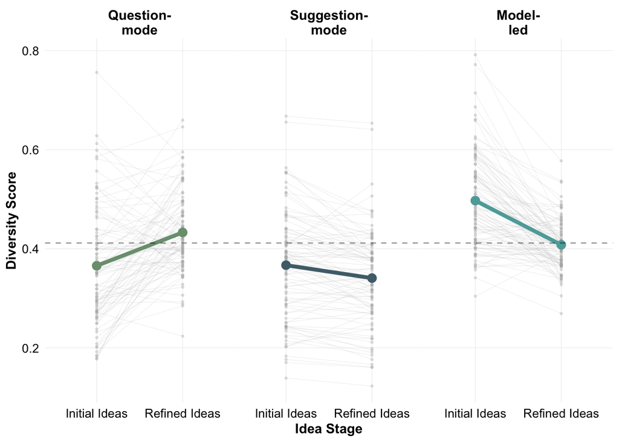

```r
# Reshape data for before-after plot with renamed bot types
before_after_data <- analysis_data %>%
  pivot_longer(cols = c(initial_diversity, refined_to_centroid),
               names_to = "timepoint",
               values_to = "diversity") %>%
  mutate(
    timepoint = factor(timepoint,
                      levels = c("initial_diversity", "refined_to_centroid"),
                      labels = c("Initial Ideas", "Refined Ideas")),
    participant_id = factor(participant_id)
  )

# Calculate means for overlay using renamed bot types
means_data <- before_after_data %>%
  group_by(bot_type_renamed, timepoint) %>%
  summarise(mean_diversity = mean(diversity, na.rm = TRUE), .groups = 'drop')

# Publication-ready before-after plot
p_within_subject <- ggplot(before_after_data, aes(x = timepoint, y = diversity, group = participant_id)) +

  # Individual trajectories (light lines)
  geom_line(alpha = 0.2, color = "gray70", size = 0.2) +
  geom_point(alpha = 0.3, size = 0.6, color = "gray70") +

  # Mean trajectories (thick lines)
  geom_line(data = means_data, aes(x = timepoint, y = mean_diversity, group = bot_type_renamed, color = bot_type_renamed),
            size = 1.5, inherit.aes = FALSE) +
  geom_point(data = means_data, aes(x = timepoint, y = mean_diversity, color = bot_type_renamed),
             size = 3, inherit.aes = FALSE) +

  # Reference line
  geom_hline(yintercept = mean(analysis_data$initial_diversity),
             linetype = "dashed", alpha = 0.4, color = "black", size = 0.5) +

  # Bot colors (use global discrete palette)
  scale_color_discrete(name = "Bot Type") +

  # Use facet_grid instead of facet_wrap for better spacing control
  facet_grid(. ~ bot_type_renamed) +

  # Clean labels
  labs(
    x = "Idea Stage",
    y = "Diversity Score"
  ) +

  # Publication theme
  theme_minimal() +
  theme(
    # Remove titles
    plot.title = element_blank(),
    plot.subtitle = element_blank(),
    plot.caption = element_blank(),

    # Facet labels with reduced margins
    strip.text = element_text(size = 11, face = "bold", color = "black",
                             margin = margin(2, 2, 2, 2)),
    strip.background = element_blank(),

    # Axis text
    axis.text = element_text(size = 10, color = "black"),
    axis.title = element_text(size = 11, face = "bold", color = "black"),

    # Remove legend completely
    legend.position = "none",

    # Panel spacing - very tight spacing between panels
    panel.spacing.x = unit(0.01, "lines"),
    panel.spacing.y = unit(0.01, "lines"),

    # Grid
    panel.grid.minor = element_blank(),
    panel.grid.major = element_line(color = "gray95", size = 0.3),

    # Minimal margins to make panels bigger
    plot.margin = margin(5, 5, 5, 5)
  )
print(p_within_subject)
```

```r
# Save with bigger dimensions to make individual panels larger
# Also save as PDF for LaTeX
ggsave(fig_path("within_subject_change_publication.pdf"), p_within_subject,
       width = 12, height = 4.5, device = "pdf", bg = "white")
```

#Violin Plot Dependent Variables

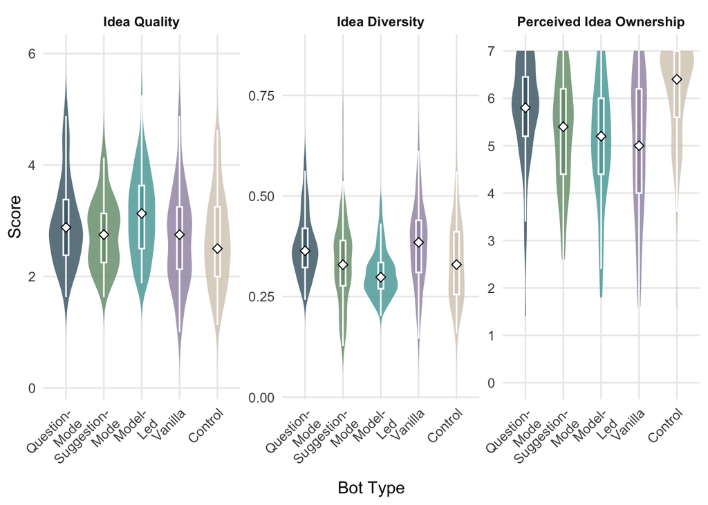

```r
idea_quality_col <- "Average"
refined_div_col <- "refined_div_condition"

data_clean <- data_clean %>%
  mutate(
    !!idea_quality_col := as.numeric(!!sym(idea_quality_col)),
    !!refined_div_col := as.numeric(!!sym(refined_div_col)),
    Perceived_Ownership = as.numeric(Perceived_Ownership)
  )

# --- Conditions and approved colors ---
# Standardized order for all graphics: Question-mode, Suggestion-mode, Model-led, Vanilla, Control
desired_levels <- c("feedback", "suggestion", "improvement", "vanilla", "control")
present_levels <- desired_levels[desired_levels %in% unique(as.character(data_clean$bot_type))]

data_clean <- data_clean %>%
  mutate(bot_type = factor(as.character(bot_type), levels = present_levels))


# Pretty labels for bot types (single-line for non-boxplot graphics)
# Note: Using the global label_map defined earlier, no need to redefine



# --- Long data for the three DVs ---
dv_vars <- c(idea_quality_col, refined_div_col, "Perceived_Ownership")
dv_labels <- setNames(
  c("Idea Quality", "Idea Diversity", "Perceived Idea Ownership"),
  dv_vars
)

plot_data <- data_clean %>%
  select(bot_type, all_of(dv_vars)) %>%
  pivot_longer(cols = all_of(dv_vars), names_to = "dv", values_to = "score") %>%
  filter(!is.na(bot_type), !is.na(score)) %>%
  mutate(
    # Limit Perceived Ownership to 0-7 range
    score = ifelse(dv == "Perceived_Ownership", pmin(pmax(score, 0), 7), score),
    dv = factor(dv, levels = dv_vars, labels = dv_labels[dv_vars])
  )

# --- Violin plot (facetted) ---
p_violin <- ggplot(plot_data, aes(x = bot_type, y = score, fill = bot_type)) +
  geom_violin(data = filter(plot_data, dv != "Perceived Idea Ownership"),
              trim = FALSE, alpha = 0.85, color = NA) +
  geom_violin(data = filter(plot_data, dv == "Perceived Idea Ownership"),
              trim = TRUE, alpha = 0.85, color = NA) +
  geom_boxplot(width = 0.14, outlier.shape = NA, color = "white", alpha = 0.95) +
  stat_summary(fun = median, geom = "point", shape = 23, size = 2.2, fill = "white") +
  facet_wrap(~ dv, scales = "free_y", ncol = 3) +
  ggh4x::facetted_pos_scales(
    y = list(
      dv == "Perceived Idea Ownership" ~ scale_y_continuous(limits = c(0, 7), breaks = seq(0, 7, 1))
    )
  ) +
  scale_x_discrete(limits = present_levels, labels = boxplot_label_map[present_levels]) +
  scale_fill_manual(values = bot_colors[present_levels],
                    breaks = present_levels,
                    labels = boxplot_label_map[present_levels],
                    limits = present_levels) +
  labs(x = "Bot Type", y = "Score") +
  guides(fill = "none") +
  theme_minimal(base_size = 12) +
  theme(panel.grid.minor = element_blank(),
        strip.text = element_text(face = "bold"),
        axis.text.x = element_text(angle = 45, hjust = 1))

print(p_violin)
```

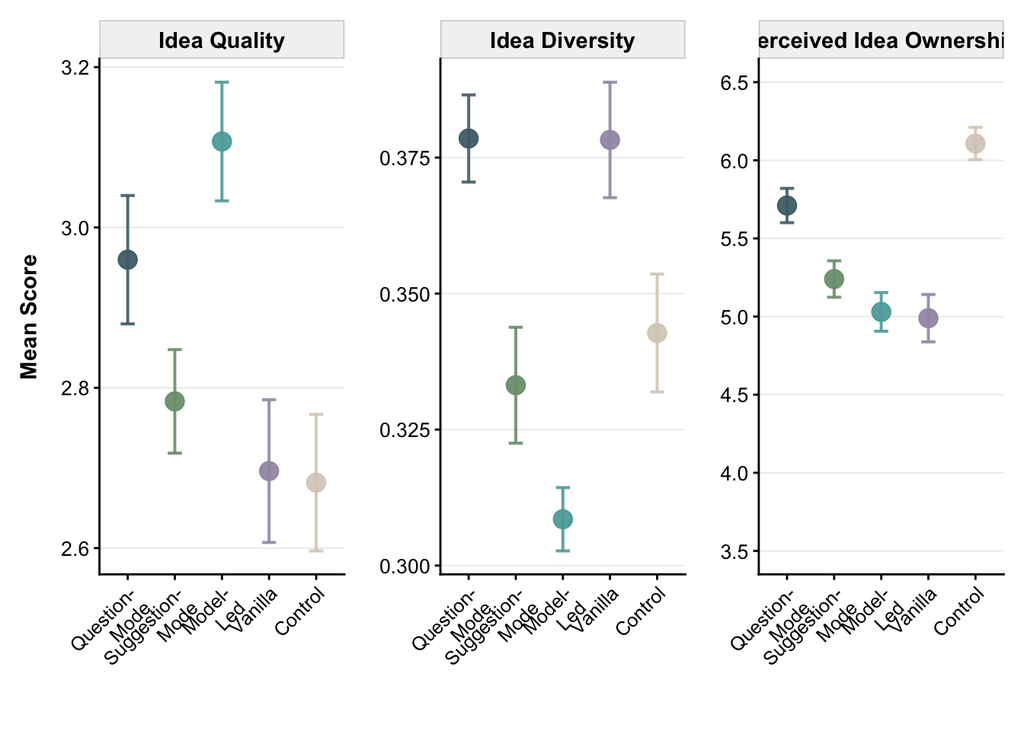

```r
# Save violin plots
dir.create(here::here("Analysis", "Figures"), showWarnings = FALSE, recursive = TRUE)
# Also save as PDF (vector graphics)
ggsave(
  filename = here::here("Analysis", "Figures", "violin_refinedSim_ideaQuality_ownership_by_condition.pdf"),
  plot = p_violin, width = 12, height = 4.5, device = "pdf", bg = "white", useDingbats = FALSE
)
# Calculate means and standard errors for each DV and bot type
dv_summary <- plot_data %>%
  group_by(bot_type, dv) %>%
  summarise(
    mean_score = mean(score, na.rm = TRUE),
    se_score = sd(score, na.rm = TRUE) / sqrt(n()),
    n = n(),
    .groups = 'drop'
  )

# Create CHI-style dot plot with error bars
p_dot_mean <- ggplot(dv_summary, aes(x = bot_type, y = mean_score, color = bot_type)) +
  # Error bars
  geom_errorbar(aes(ymin = mean_score - se_score, ymax = mean_score + se_score),
                width = 0.3, size = 0.7, alpha = 0.9) +
  # Data points (means)
  geom_point(size = 4, alpha = 0.95) +

  # Faceting by DV
  facet_wrap(~ dv, scales = "free_y", ncol = 3) +
  ggh4x::facetted_pos_scales(
    y = list(
      dv == "Perceived Idea Ownership" ~ scale_y_continuous(limits = c(3.5, 6.5), breaks = seq(3.5, 6.5, 0.5))
    )
  ) +

  # Color scheme
  scale_x_discrete(limits = present_levels, labels = boxplot_label_map[present_levels]) +
  scale_color_manual(values = bot_colors[present_levels],
                     breaks = present_levels,
                     labels = boxplot_label_map[present_levels],
                     limits = present_levels) +

  # Labels and theme
  labs(x = "", y = "Mean Score") +
  guides(color = "none") +
  theme_classic(base_size = 11) +
  theme(
    # Facet styling
    strip.text = element_text(face = "bold", size = 11, color = "black"),
    strip.background = element_rect(fill = "grey95", color = "grey80", size = 0.5),

    # Axis styling
    axis.text.x = element_text(size = 9.5, angle = 45, hjust = 1, color = "black"),
    axis.text.y = element_text(size = 10, color = "black"),
    axis.title.y = element_text(size = 11, face = "bold", margin = margin(r = 10)),
    axis.line = element_line(color = "black", size = 0.5),
    axis.ticks = element_line(color = "black", size = 0.5),

    # Panel styling
    panel.background = element_rect(fill = "white", color = NA),
    plot.background = element_rect(fill = "white", color = NA),
    panel.grid.major.y = element_line(color = "grey92", size = 0.3),
    panel.grid.major.x = element_blank(),
    panel.grid.minor = element_blank(),

    # Spacing
    panel.spacing = unit(1.2, "lines"),
    plot.margin = margin(10, 10, 10, 10)
  )
print(p_dot_mean)
```

```r
# Save publication-ready dot plot
ggsave(
  filename = here::here("Analysis", "Figures", "dotplot_refinedSim_ideaQuality_ownership_by_condition_chi.pdf"),
  plot = p_dot_mean, width = 12, height = 4.5, device = "pdf", bg = "white", useDingbats = FALSE
)
```

#Violin Plot Cognitive Workload

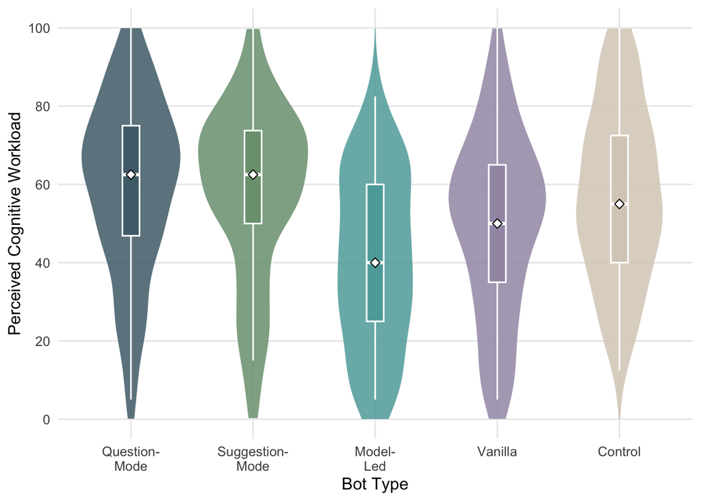

```r
# Custom bot order for TLX violin: Question-mode, Suggestion-mode, Model-led, Vanilla, Control
desired_levels_tlx <- c("feedback", "suggestion", "improvement", "vanilla", "control")
present_levels_tlx <- desired_levels_tlx[desired_levels_tlx %in% unique(as.character(data_clean$bot_type))]

# Prepare data for composite NASA-TLX measure
tlx_data <- data_clean %>%
  dplyr::select(bot_type, NASA_TLX) %>%
  dplyr::filter(!is.na(bot_type), !is.na(NASA_TLX)) %>%
  dplyr::mutate(bot_type = factor(as.character(bot_type), levels = present_levels_tlx))

p_tlx_violin <- ggplot2::ggplot(tlx_data, ggplot2::aes(x = bot_type, y = NASA_TLX, fill = bot_type)) +
  ggplot2::geom_violin(trim = FALSE, alpha = 0.85, color = NA) +
  ggplot2::geom_boxplot(width = 0.14, outlier.shape = NA, color = "white", alpha = 0.95) +
  ggplot2::stat_summary(fun = median, geom = "point", shape = 23, size = 2.2, fill = "white") +
  ggplot2::scale_x_discrete(limits = present_levels_tlx, labels = boxplot_label_map[present_levels_tlx]) +
  ggplot2::scale_fill_manual(values = bot_colors[present_levels_tlx],
                             breaks = present_levels_tlx,
                             labels = boxplot_label_map[present_levels_tlx],
                             limits = present_levels_tlx) +
  ggplot2::labs(x = "Bot Type", y = "Perceived Cognitive Workload") +
  ggplot2::scale_y_continuous(limits = c(0, 100), breaks = seq(0, 100, 20)) +
  ggplot2::guides(fill = "none") +
  ggplot2::theme_minimal(base_size = 12) +
  ggplot2::theme(panel.grid.minor = ggplot2::element_blank())

print(p_tlx_violin)
```

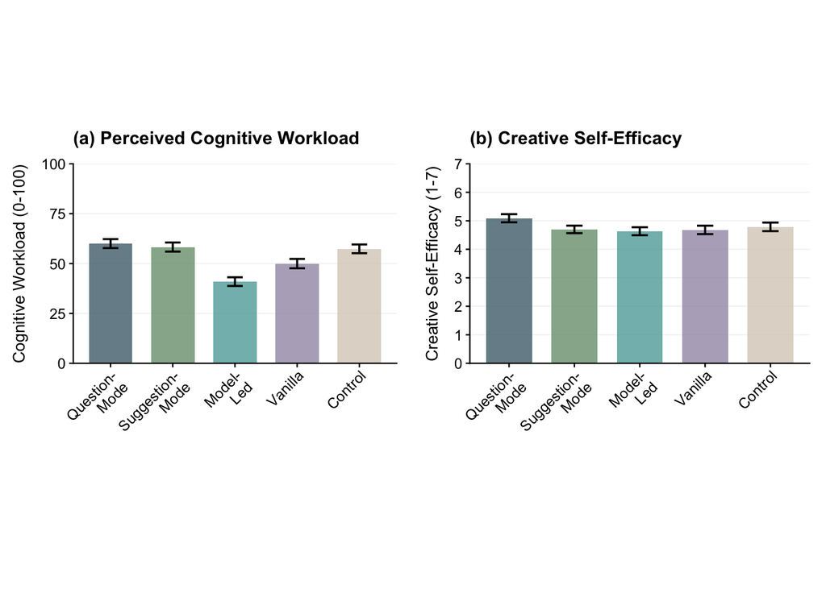

```r
# Create bar charts for cognitive workload and creative self-efficacy
# Prepare data for bar charts - calculate means and standard errors
bar_data <- data_clean %>%
  dplyr::filter(!is.na(bot_type)) %>%
  dplyr::mutate(bot_type = factor(as.character(bot_type), levels = present_levels_tlx)) %>%
  dplyr::group_by(bot_type) %>%
  dplyr::summarise(
    NASA_TLX_mean = mean(NASA_TLX, na.rm = TRUE),
    NASA_TLX_se = sd(NASA_TLX, na.rm = TRUE) / sqrt(n()),
    Creative_Self_Efficacy_mean = mean(Creative_Self_Efficacy, na.rm = TRUE),
    Creative_Self_Efficacy_se = sd(Creative_Self_Efficacy, na.rm = TRUE) / sqrt(n()),
    n = n(),
    .groups = 'drop'
  ) %>%
  dplyr::filter(!is.na(bot_type))


# Create cognitive workload bar chart (ACM/CHI publication style)
p_tlx_bar <- ggplot2::ggplot(bar_data, ggplot2::aes(x = bot_type, y = NASA_TLX_mean, fill = bot_type)) +
  ggplot2::geom_col(alpha = 0.8, color = NA, width = 0.7) +
  ggplot2::geom_errorbar(ggplot2::aes(ymin = pmax(0, NASA_TLX_mean - NASA_TLX_se),
                                      ymax = pmin(100, NASA_TLX_mean + NASA_TLX_se)),
                         width = 0.25, size = 0.6, color = "black") +
  ggplot2::scale_x_discrete(limits = present_levels_tlx, labels = boxplot_label_map[present_levels_tlx]) +
  ggplot2::scale_fill_manual(values = bot_colors[present_levels_tlx],
                             breaks = present_levels_tlx,
                             labels = boxplot_label_map[present_levels_tlx],
                             limits = present_levels_tlx) +
  ggplot2::labs(x = "", y = "Cognitive Workload (0-100)", title = "(a) Perceived Cognitive Workload") +
  ggplot2::scale_y_continuous(limits = c(0, 100), breaks = seq(0, 100, 25), expand = c(0, 0)) +
  ggplot2::guides(fill = "none") +
  ggplot2::theme_classic(base_size = 10) +
  ggplot2::theme(
    plot.title = ggplot2::element_text(hjust = 0, size = 11, face = "bold", margin = ggplot2::margin(b = 10)),
    axis.title.y = ggplot2::element_text(size = 10, margin = ggplot2::margin(r = 8)),
    axis.text.x = ggplot2::element_text(size = 9, angle = 45, hjust = 1, margin = ggplot2::margin(t = 1)),
    axis.text.y = ggplot2::element_text(size = 9),
    axis.line = ggplot2::element_line(color = "black", size = 0.4),
    axis.ticks = ggplot2::element_line(color = "black", size = 0.4),
    panel.background = ggplot2::element_rect(fill = "white", color = NA),
    plot.background = ggplot2::element_rect(fill = "white", color = NA),
    panel.grid.major.y = ggplot2::element_line(color = "gray95", size = 0.3),
    panel.grid.major.x = ggplot2::element_blank(),
    plot.margin = ggplot2::margin(8, 10, 4, 8)
  )

# Create creative self-efficacy bar chart (ACM/CHI publication style)
p_cse_bar <- ggplot2::ggplot(bar_data, ggplot2::aes(x = bot_type, y = Creative_Self_Efficacy_mean, fill = bot_type)) +
  ggplot2::geom_col(alpha = 0.8, color = NA, width = 0.7) +
  ggplot2::geom_errorbar(ggplot2::aes(ymin = pmax(0, Creative_Self_Efficacy_mean - Creative_Self_Efficacy_se),
                                      ymax = pmin(7, Creative_Self_Efficacy_mean + Creative_Self_Efficacy_se)),
                         width = 0.25, size = 0.6, color = "black") +
  ggplot2::scale_x_discrete(limits = present_levels_tlx, labels = boxplot_label_map[present_levels_tlx]) +
  ggplot2::scale_fill_manual(values = bot_colors[present_levels_tlx],
                             breaks = present_levels_tlx,
                             labels = boxplot_label_map[present_levels_tlx],
                             limits = present_levels_tlx) +
  ggplot2::labs(x = "", y = "Creative Self-Efficacy (1-7)", title = "(b) Creative Self-Efficacy") +
  ggplot2::scale_y_continuous(limits = c(0, 7), breaks = seq(0, 7, 1), expand = c(0, 0)) +
  ggplot2::guides(fill = "none") +
  ggplot2::theme_classic(base_size = 10) +
  ggplot2::theme(
    plot.title = ggplot2::element_text(hjust = 0, size = 11, face = "bold", margin = ggplot2::margin(b = 10)),
    axis.title.y = ggplot2::element_text(size = 10, margin = ggplot2::margin(r = 8)),
    axis.text.x = ggplot2::element_text(size = 9, angle = 45, hjust = 1, margin = ggplot2::margin(t = 1)),
    axis.text.y = ggplot2::element_text(size = 9),
    axis.line = ggplot2::element_line(color = "black", size = 0.4),
    axis.ticks = ggplot2::element_line(color = "black", size = 0.4),
    panel.background = ggplot2::element_rect(fill = "white", color = NA),
    plot.background = ggplot2::element_rect(fill = "white", color = NA),
    panel.grid.major.y = ggplot2::element_line(color = "gray95", size = 0.3),
    panel.grid.major.x = ggplot2::element_blank(),
    plot.margin = ggplot2::margin(8, 10, 4, 8)
  )

# Combine bar charts side by side with minimal spacing
combined_bar_plot <- gridExtra::grid.arrange(
  p_tlx_bar, p_cse_bar,
  ncol = 2,
  heights = unit(3, "in"),
  widths = unit.c(unit(3.5, "in"), unit(3.5, "in"))
)
```

```r
print(combined_bar_plot)
```

```r
# Save outputs
dir.create(here::here("Analysis", "Figures"), showWarnings = FALSE, recursive = TRUE)

# Save violin plots
ggplot2::ggsave(
  filename = here::here("Analysis", "Figures", "violin_cognitive_workload_by_condition.pdf"),
  plot = p_tlx_violin, width = 7, height = 4.5, device = "pdf", bg = "white", useDingbats = FALSE
)
# Save bar charts (ACM/CHI publication quality)
ggplot2::ggsave(
  filename = here::here("Analysis", "Figures", "bar_cognitive_workload_creativeSE_by_condition.pdf"),
  plot = combined_bar_plot, width = 7, height = 3.5, device = "pdf", bg = "white",
  useDingbats = FALSE, units = "in"
)

# Save individual charts for single-column figures if needed
ggplot2::ggsave(
  filename = here::here("Analysis", "Figures", "bar_cognitive_workload_publication.pdf"),
  plot = p_tlx_bar, width = 3.5, height = 3, device = "pdf", bg = "white",
  useDingbats = FALSE, units = "in"
)
ggplot2::ggsave(
  filename = here::here("Analysis", "Figures", "bar_creative_self_efficacy_publication.pdf"),
  plot = p_cse_bar, width = 3.5, height = 3, device = "pdf", bg = "white",
  useDingbats = FALSE, units = "in"
)
```

# UX Measures Spider Plot

```r
# Ensure figures directory exists
dir.create(fig_path(), showWarnings = FALSE, recursive = TRUE)

# Clean the elaboration data and extract participant_id
elaboration_clean <- elaboration_data %>%
  rename(bot_type_elab = Condition) %>%
  mutate(
    Overall = as.numeric(Overall),
    participant_id = as.character(participant_id)
  ) %>%
  select(participant_id, bot_type_elab, Overall) %>%
  filter(!is.na(Overall))

# Define the UX measures we want to include in the spider plot
ux_measures <- c(
  "Performance_Expectancy",
  "Effort_Expectancy",
  "Hedonic_Motivation",
  "Perceived_Ownership",
  "Creative_Self_Efficacy",  # Added creative self-efficacy
  "Mental_Load",  # Combined mental demand and mental effort
  "Elaboration_Depth"  # From Overall Score
)

# Create readable labels for the spider plot
ux_measure_labels <- c(
  "Performance\nExpectancy",
  "Effort\nExpectancy",
  "Hedonic\nMotivation",
  "Perceived\nOwnership",
  "Creative\nSelf-Efficacy",  # Added label for creative self-efficacy
  "Perceived\n Cognitive\nWorkload",  # Combined label
  "Elaboration Depth"
)

# Calculate group means for each bot type and UX measure
# Standardized bot order for all graphics: Question-mode, Suggestion-mode, Model-led, Vanilla, Control
bot_order <- c("feedback", "suggestion", "improvement", "vanilla", "control")

# First calculate the regular UX measures
ux_spider_data <- data_clean %>%
  # Only include bot types that have UX measures (exclude control group)
  filter(bot_type %in% bot_order & bot_type != "control") %>%
  group_by(bot_type) %>%
  summarise(
    Performance_Expectancy = mean(Performance_Expectancy, na.rm = TRUE),
    Effort_Expectancy = mean(Effort_Expectancy, na.rm = TRUE),
    Hedonic_Motivation = mean(Hedonic_Motivation, na.rm = TRUE),
    Perceived_Ownership = mean(Perceived_Ownership, na.rm = TRUE),
    Creative_Self_Efficacy = mean(Creative_Self_Efficacy, na.rm = TRUE),  # Added creative self-efficacy
    NASA_TLX = mean(NASA_TLX, na.rm = TRUE),  # Added NASA_TLX for Mental Load
    .groups = "drop"
  )

# Now add elaboration depth from the data
elaboration_means <- elaboration_clean %>%
  group_by(bot_type_elab) %>%
  summarise(Elaboration_Depth = mean(Overall, na.rm = TRUE), .groups = "drop") %>%
  rename(bot_type = bot_type_elab)

# Merge elaboration data with UX data
ux_spider_data <- ux_spider_data %>%
  left_join(elaboration_means, by = "bot_type") %>%
  # Remove rows with all NA values
  filter(!is.na(Performance_Expectancy) | !is.na(NASA_TLX)) %>%
  # Ensure the order is correct so suggestion is plotted last
  arrange(match(bot_type, bot_order))

print(ux_spider_data)
```

```
## # A tibble: 4 × 8
##   bot_type    Performance_Expectancy Effort_Expectancy Hedonic_Motivation
##   <chr>                        <dbl>             <dbl>              <dbl>
## 1 feedback                      5.76              6.12               5.43
## 2 suggestion                    5.13              5.77               4.85
## 3 improvement                   5.60              6.09               5.31
## 4 vanilla                       5.44              5.76               5.15
## # ℹ 4 more variables: Perceived_Ownership <dbl>, Creative_Self_Efficacy <dbl>,
## #   NASA_TLX <dbl>, Elaboration_Depth <dbl>
```

```r
# Transform all measures to consistent 1-7 scale for better interpretation
# 7-point scales (1-7) -> keep as is
# tlx1 & tlx2 (0-100) -> transform to 1-7 scale
# Overall Score (1-5) -> transform to 1-7 scale

print(ux_spider_data %>% select(bot_type, Elaboration_Depth))
```

```
## # A tibble: 4 × 2
##   bot_type    Elaboration_Depth
##   <chr>                   <dbl>
## 1 feedback                 3.4
## 2 suggestion               1.95
## 3 improvement              1.1
## 4 vanilla                  2.35
```

```r
ux_spider_normalized <- ux_spider_data %>%
  mutate(
    # Keep 7-point scales as is (1-7)
    Performance_Expectancy = Performance_Expectancy,
    Effort_Expectancy = Effort_Expectancy,
    Hedonic_Motivation = Hedonic_Motivation,
    Perceived_Ownership = Perceived_Ownership,
    Creative_Self_Efficacy = Creative_Self_Efficacy,  # Added - keep as is (1-7 scale)

    # Transform 5-point scale (1-5) to 7-point scale (1-7) for Overall Score
    Elaboration_Depth = 1 + ((Elaboration_Depth - 1) / 4) * 6,  # Maps 1→1, 5→7

    # Transform NASA-TLX to 1-7 scale and rename to Mental_Load for spider plot
    Mental_Load = 1 + (NASA_TLX / 100) * 6  # Maps 0→1, 100→7 (NASA-TLX Mental Load)
  )

print(ux_spider_normalized)
```

```
## # A tibble: 4 × 9
##   bot_type    Performance_Expectancy Effort_Expectancy Hedonic_Motivation
##   <chr>                        <dbl>             <dbl>              <dbl>
## 1 feedback                      5.76              6.12               5.43
## 2 suggestion                    5.13              5.77               4.85
## 3 improvement                   5.60              6.09               5.31
## 4 vanilla                       5.44              5.76               5.15
## # ℹ 5 more variables: Perceived_Ownership <dbl>, Creative_Self_Efficacy <dbl>,
## #   NASA_TLX <dbl>, Elaboration_Depth <dbl>, Mental_Load <dbl>
```

```r
# Prepare final data for radarchart (fmsb format)
ux_radar_data <- ux_spider_normalized %>%
  select(all_of(ux_measures)) %>%
  as.data.frame()

# Set column names to readable labels
colnames(ux_radar_data) <- ux_measure_labels

# Add max and min rows (required by fmsb) - now using 1-7 scale
max_row <- rep(7, ncol(ux_radar_data))
min_row <- rep(1, ncol(ux_radar_data))

ux_radar_final <- rbind(max_row, min_row, ux_radar_data)

# Create bot labels using existing label_map
present_bot_types <- as.character(ux_spider_normalized$bot_type)
ux_bot_labels <- sapply(present_bot_types, function(x) {
  # Use single-line labels for spider plot
  label <- label_map[x]
  if(is.na(label)) label <- x
  # Return label as-is (no line breaks to remove)
  label
})

# Set row names
rownames(ux_radar_final) <- c("Max", "Min", ux_bot_labels)

print("Final UX radar data for plotting:")
```

```
## [1] "Final UX radar data for plotting:"
```

```r
print(ux_radar_final)
```

```
##                 Performance\nExpectancy Effort\nExpectancy Hedonic\nMotivation
## Max                            7.000000           7.000000            7.000000
## Min                            1.000000           1.000000            1.000000
## Question-Mode                  5.760417           6.122396            5.430556
## Suggestion-Mode                5.133333           5.765789            4.845614
## Model-Led                      5.603960           6.086634            5.310231
## Vanilla                        5.442105           5.755263            5.154386
##                 Perceived\nOwnership Creative\nSelf-Efficacy
## Max                         7.000000                7.000000
## Min                         1.000000                1.000000
## Question-Mode               5.710417                5.090278
## Suggestion-Mode             5.240000                4.698246
## Model-Led                   5.029703                4.633663
## Vanilla                     4.989474                4.680702
##                 Perceived\n Cognitive\nWorkload Elaboration Depth
## Max                                    7.000000             7.000
## Min                                    1.000000             1.000
## Question-Mode                          4.600000             4.600
## Suggestion-Mode                        4.495789             2.425
## Model-Led                              3.456436             1.150
## Vanilla                                3.998421             3.025
```

```r
# Use original bot_colors palette for publication consistency
ux_radar_colors <- sapply(present_bot_types, function(x) {
  color_hex <- bot_colors[x]
  if(is.na(color_hex)) color_hex <- "#808080"  # Default gray
  # Convert to RGB with professional transparency for CHI publication
  rgb_vals <- col2rgb(color_hex)
  rgb(rgb_vals[1], rgb_vals[2], rgb_vals[3], alpha = 70, maxColorValue = 255)
})

ux_radar_border_colors <- sapply(present_bot_types, function(x) {
  color_hex <- bot_colors[x]
  if(is.na(color_hex)) color_hex <- "#808080"
  color_hex
})

print("Bot types for UX spider plot:")
```

```
## [1] "Bot types for UX spider plot:"
```

```r
print(present_bot_types)
```

```
## [1] "feedback"    "suggestion"  "improvement" "vanilla"
```

```r
print("UX Legend labels:")
```

```
## [1] "UX Legend labels:"
```

```r
print(ux_bot_labels)
```

```
##       feedback.feedback   suggestion.suggestion improvement.improvement
##         "Question-Mode"       "Suggestion-Mode"             "Model-Led"
##         vanilla.vanilla
##               "Vanilla"
```

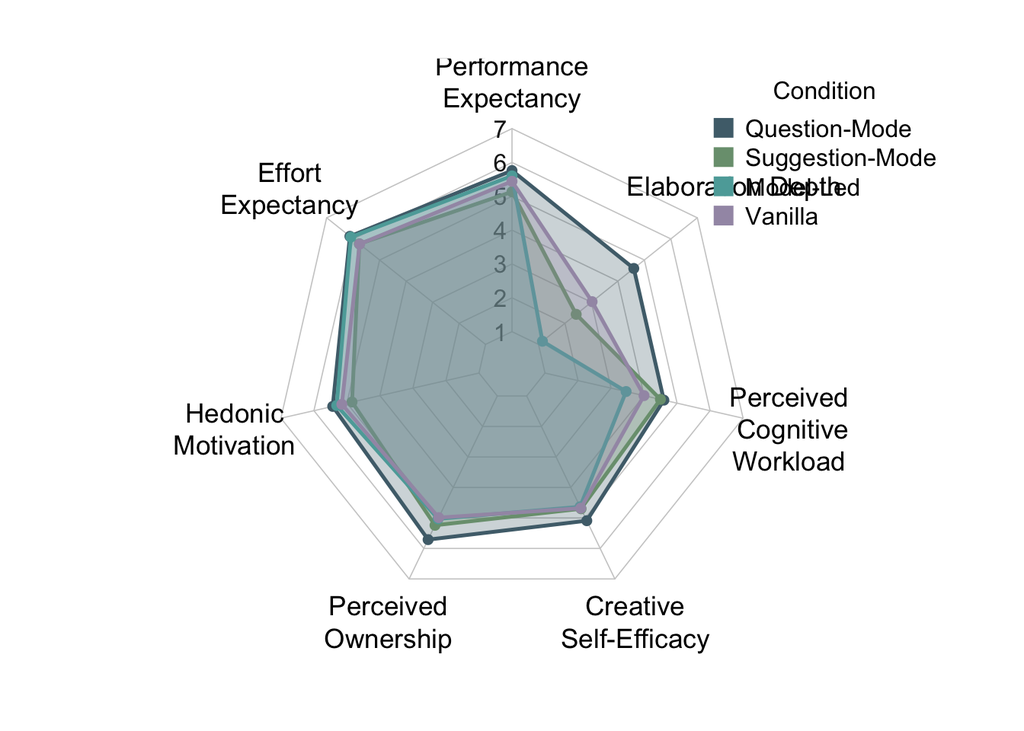

```r
# Set up the plot area
par(mar = c(2, 2, 2, 2), mfrow = c(1, 1))

# Create radar chart with CHI publication styling
radarchart(
  ux_radar_final,
  # Axis settings
  axistype = 1,
  maxmin = TRUE,

  # Grid settings (professional, subtle)
  cglcol = "grey80",
  cglty = 1,
  cglwd = 0.8,

  # Axis labels (1-7 scale)
  axislabcol = "grey10",
  caxislabels = seq(1, 7, 1),
  calcex = 1.0,

  # Polygon settings (professional colors and line weights)
  pcol = ux_radar_border_colors,
  pfcol = ux_radar_colors,
  plwd = 2.5,  # Professional line weight
  plty = 1,

  # Variable label settings (publication appropriate)
  vlcex = 1.1,
  vlabels = colnames(ux_radar_final),

  # Grid segments for 1-7 scale (6 segments for 7 labels)
  seg = 6
)

# Add professional legend for CHI - positioned to avoid overlap with labels
legend(
  x = 0.8, y = 1.25,
  legend = ux_bot_labels,
  bty = "n",
  pch = 15,  # Square symbols for better printing
  col = ux_radar_border_colors,
  text.col = "black",
  cex = 1.0,
  pt.cex = 1.8,
  title = "Condition",
  title.col = "black",
  title.cex = 1.0
)
```

```r
# Also create PDF version  (vector graphics for LaTeX)
pdf(fig_path("ux_measures_spider_chart.pdf"), width = 10, height = 8, useDingbats = FALSE)

par(mar = c(2, 2, 2, 2), mfrow = c(1, 1))

radarchart(
  ux_radar_final,
  axistype = 1,
  maxmin = TRUE,
  cglcol = "grey80",
  cglty = 1,
  cglwd = 0.8,
  axislabcol = "grey10",
  caxislabels = seq(1, 7, 1),
  calcex = 1.0,
  pcol = ux_radar_border_colors,
  pfcol = ux_radar_colors,
  plwd = 2.5,
  plty = 1,
  vlcex = 1.1,
  vlabels = colnames(ux_radar_final),
  seg = 6
)

legend(
  x = 0.8, y = 1.25,
  legend = ux_bot_labels,
  bty = "n",
  pch = 15,
  col = ux_radar_border_colors,
  text.col = "black",
  cex = 1.0,
  pt.cex = 1.8,
  title = "Condition",
  title.col = "black",
  title.cex = 1.0
)

dev.off()
```

# ROBUSTNESS CHECKS

This section presents robustness checks for the three main dependent variables: Idea Quality, Idea Diversity, and Perceived Ownership. These checks assess whether the main findings are robust to alternative modeling approaches and distributional assumptions.

## 1. Idea Quality Robustness Checks

### 1.1 Kruskal-Wallis Non-Parametric Test

The Kruskal-Wallis test is a non-parametric alternative to ANOVA that does not assume normality or equal variances. It tests whether the distribution of quality ratings differs across bot types.

```r
# Kruskal-Wallis test
kw_quality <- kruskal.test(Average ~ bot_type, data = data_clean)
kw_quality
```

```
##
##  Kruskal-Wallis rank sum test
##
## data:  Average by bot_type
## Kruskal-Wallis chi-squared = 20.504, df = 4, p-value = 0.0003971
```

```r
# Effect size for overall test
kw_effsize_quality <- kruskal_effsize(Average ~ bot_type, data = data_clean)
kw_effsize_quality
```

```
## # A tibble: 1 × 5
##   .y.         n effsize method  magnitude
## * <chr>   <int>   <dbl> <chr>   <ord>
## 1 Average   486  0.0343 eta2[H] small
```

```r
# Dunn's post-hoc test with Holm adjustment and one-sided p-values
dunn_quality <- dunn_test(Average ~ bot_type, data = data_clean, p.adjust.method = "holm") %>%
  mutate(
    r = statistic / sqrt(n1 + n2),
    p_one_sided = ifelse(statistic > 0, p / 2, 1 - p / 2),
    p.adj_one_sided = ifelse(statistic > 0, p.adj / 2, 1 - p.adj / 2)
  )
dunn_quality
```

```
## # A tibble: 10 × 12
##    .y.     group1      group2    n1    n2 statistic       p   p.adj p.adj.signif
##    <chr>   <chr>       <chr>  <int> <int>     <dbl>   <dbl>   <dbl> <chr>
##  1 Average feedback    sugge…    96    95    -1.15  2.51e-1 1       ns
##  2 Average feedback    impro…    96   101     1.61  1.07e-1 0.534   ns
##  3 Average feedback    vanil…    96    95    -2.00  4.60e-2 0.276   ns
##  4 Average feedback    contr…    96    99    -2.23  2.57e-2 0.180   ns
##  5 Average suggestion  impro…    95   101     2.77  5.57e-3 0.0446  *
##  6 Average suggestion  vanil…    95    95    -0.844 3.99e-1 1       ns
##  7 Average suggestion  contr…    95    99    -1.07  2.86e-1 1       ns
##  8 Average improvement vanil…   101    95    -3.63  2.85e-4 0.00256 **
##  9 Average improvement contr…   101    99    -3.88  1.03e-4 0.00103 **
## 10 Average vanilla     contr…    95    99    -0.214 8.31e-1 1       ns
## # ℹ 3 more variables: r <dbl>, p_one_sided <dbl>, p.adj_one_sided <dbl>
```

## 2. Idea Diversity Robustness Checks

### 2.1 Kruskal-Wallis Non-Parametric Test

The Kruskal-Wallis test is a non-parametric alternative to ANOVA that does not assume normality or equal variances. It tests whether the distribution of diversity scores differs across bot types.

```r
# Kruskal-Wallis test
kw_div <- kruskal.test(refined_div_condition ~ bot_type, data = data_clean)
kw_div
```

```
##
##  Kruskal-Wallis rank sum test
##
## data:  refined_div_condition by bot_type
## Kruskal-Wallis chi-squared = 46.105, df = 4, p-value = 2.342e-09
```

```r
# Effect size for overall test
kw_effsize_div <- kruskal_effsize(refined_div_condition ~ bot_type, data = data_clean)
kw_effsize_div
```

```
## # A tibble: 1 × 5
##   .y.                       n effsize method  magnitude
## * <chr>                 <int>   <dbl> <chr>   <ord>
## 1 refined_div_condition   486  0.0875 eta2[H] moderate
```

```r
# Dunn's post-hoc test with Holm adjustment and one-sided p-values
dunn_div <- dunn_test(refined_div_condition ~ bot_type, data = data_clean, p.adjust.method = "holm") %>%
  mutate(
    r = statistic / sqrt(n1 + n2),
    p_one_sided = ifelse(statistic > 0, p / 2, 1 - p / 2),
    p.adj_one_sided = ifelse(statistic > 0, p.adj / 2, 1 - p.adj / 2)
  )
dunn_div
```

```
## # A tibble: 10 × 12
##    .y.          group1 group2    n1    n2 statistic       p   p.adj p.adj.signif
##    <chr>        <chr>  <chr>  <int> <int>     <dbl>   <dbl>   <dbl> <chr>
##  1 refined_div… feedb… sugge…    96    95    -3.25  1.14e-3 9.09e-3 **
##  2 refined_div… feedb… impro…    96   101    -5.72  1.10e-8 1.10e-7 ****
##  3 refined_div… feedb… vanil…    96    95    -0.140 8.89e-1 1   e+0 ns
##  4 refined_div… feedb… contr…    96    99    -3.08  2.04e-3 1.32e-2 *
##  5 refined_div… sugge… impro…    95   101    -2.40  1.62e-2 4.86e-2 *
##  6 refined_div… sugge… vanil…    95    95     3.11  1.89e-3 1.32e-2 *
##  7 refined_div… sugge… contr…    95    99     0.204 8.38e-1 1   e+0 ns
##  8 refined_div… impro… vanil…   101    95     5.56  2.72e-8 2.45e-7 ****
##  9 refined_div… impro… contr…   101    99     2.64  8.37e-3 3.35e-2 *
## 10 refined_div… vanil… contr…    95    99    -2.93  3.34e-3 1.67e-2 *
## # ℹ 3 more variables: r <dbl>, p_one_sided <dbl>, p.adj_one_sided <dbl>
```

### 2.2 Kruskal-Wallis Test for Logit-Transformed Diversity

```r
# Kruskal-Wallis test for logit-transformed diversity
kw_div_logit <- kruskal.test(refined_div_condition_logit ~ bot_type, data = data_clean)
kw_div_logit
```

```
##
##  Kruskal-Wallis rank sum test
##
## data:  refined_div_condition_logit by bot_type
## Kruskal-Wallis chi-squared = 46.105, df = 4, p-value = 2.342e-09
```

```r
# Effect size for overall test
kw_effsize_div_logit <- kruskal_effsize(refined_div_condition_logit ~ bot_type, data = data_clean)
kw_effsize_div_logit
```

```
## # A tibble: 1 × 5
##   .y.                             n effsize method  magnitude
## * <chr>                       <int>   <dbl> <chr>   <ord>
## 1 refined_div_condition_logit   486  0.0875 eta2[H] moderate
```

```r
# Dunn's post-hoc test with Holm adjustment and one-sided p-values
dunn_div_logit <- dunn_test(refined_div_condition_logit ~ bot_type, data = data_clean, p.adjust.method = "holm") %>%
  mutate(
    r = statistic / sqrt(n1 + n2),
    p_one_sided = ifelse(statistic > 0, p / 2, 1 - p / 2),
    p.adj_one_sided = ifelse(statistic > 0, p.adj / 2, 1 - p.adj / 2)
  )
dunn_div_logit
```

```
## # A tibble: 10 × 12
##    .y.          group1 group2    n1    n2 statistic       p   p.adj p.adj.signif
##    <chr>        <chr>  <chr>  <int> <int>     <dbl>   <dbl>   <dbl> <chr>
##  1 refined_div… feedb… sugge…    96    95    -3.25  1.14e-3 9.09e-3 **
##  2 refined_div… feedb… impro…    96   101    -5.72  1.10e-8 1.10e-7 ****
##  3 refined_div… feedb… vanil…    96    95    -0.140 8.89e-1 1   e+0 ns
##  4 refined_div… feedb… contr…    96    99    -3.08  2.04e-3 1.32e-2 *
##  5 refined_div… sugge… impro…    95   101    -2.40  1.62e-2 4.86e-2 *
##  6 refined_div… sugge… vanil…    95    95     3.11  1.89e-3 1.32e-2 *
##  7 refined_div… sugge… contr…    95    99     0.204 8.38e-1 1   e+0 ns
##  8 refined_div… impro… vanil…   101    95     5.56  2.72e-8 2.45e-7 ****
##  9 refined_div… impro… contr…   101    99     2.64  8.37e-3 3.35e-2 *
## 10 refined_div… vanil… contr…    95    99    -2.93  3.34e-3 1.67e-2 *
## # ℹ 3 more variables: r <dbl>, p_one_sided <dbl>, p.adj_one_sided <dbl>
```

## 3. Perceived Ownership Robustness Checks

### 3.1 Kruskal-Wallis Non-Parametric Test

Perceived ownership is measured on a 7-point Likert scale, which has ordinal properties. The Kruskal-Wallis test is appropriate for ordinal data and does not assume normality.

```r
# Kruskal-Wallis test
kw_owner <- kruskal.test(Perceived_Ownership ~ bot_type, data = data_clean)
kw_owner
```

```
##
##  Kruskal-Wallis rank sum test
##
## data:  Perceived_Ownership by bot_type
## Kruskal-Wallis chi-squared = 61.958, df = 4, p-value = 1.124e-12
```

```r
# Effect size for overall test
kw_effsize_owner <- kruskal_effsize(Perceived_Ownership ~ bot_type, data = data_clean)
kw_effsize_owner
```

```
## # A tibble: 1 × 5
##   .y.                     n effsize method  magnitude
## * <chr>               <int>   <dbl> <chr>   <ord>
## 1 Perceived_Ownership   486   0.120 eta2[H] moderate
```

```r
# Dunn's post-hoc test with Holm adjustment and one-sided p-values
dunn_owner <- dunn_test(Perceived_Ownership ~ bot_type, data = data_clean, p.adjust.method = "holm") %>%
  mutate(
    r = statistic / sqrt(n1 + n2),
    p_one_sided = ifelse(statistic > 0, p / 2, 1 - p / 2),
    p.adj_one_sided = ifelse(statistic > 0, p.adj / 2, 1 - p.adj / 2)
  )
dunn_owner
```

```
## # A tibble: 10 × 12
##    .y.        group1 group2    n1    n2 statistic        p    p.adj p.adj.signif
##    <chr>      <chr>  <chr>  <int> <int>     <dbl>    <dbl>    <dbl> <chr>
##  1 Perceived… feedb… sugge…    96    95    -2.90  3.70e- 3 1.85e- 2 *
##  2 Perceived… feedb… impro…    96   101    -3.88  1.06e- 4 7.44e- 4 ***
##  3 Perceived… feedb… vanil…    96    95    -3.42  6.16e- 4 3.70e- 3 **
##  4 Perceived… feedb… contr…    96    99     2.62  8.71e- 3 3.49e- 2 *
##  5 Perceived… sugge… impro…    95   101    -0.926 3.54e- 1 1   e+ 0 ns
##  6 Perceived… sugge… vanil…    95    95    -0.520 6.03e- 1 1   e+ 0 ns
##  7 Perceived… sugge… contr…    95    99     5.54  3.01e- 8 2.41e- 7 ****
##  8 Perceived… impro… vanil…   101    95     0.398 6.91e- 1 1   e+ 0 ns
##  9 Perceived… impro… contr…   101    99     6.56  5.27e-11 5.27e-10 ****
## 10 Perceived… vanil… contr…    95    99     6.07  1.31e- 9 1.18e- 8 ****
## # ℹ 3 more variables: r <dbl>, p_one_sided <dbl>, p.adj_one_sided <dbl>
```